# P1

**TITLE**

Comparative Analysis of Denoising Methods for ECG Arrhythmia Detection: Performance Evaluation Using MIT-BIH and PTB Databases

**AIM**

To evaluate and compare the effectiveness of classical signal processing, adaptive filtering, and machine learning denoising methods for improving ECG signal quality and arrhythmia detection accuracy in noisy clinical environments.

**RESEARCH OBJECTIVES**

- Implement and compare classical signal processing, adaptive filtering, and machine learning denoising methods for ECG signals contaminated with clinical noise types.
- Evaluate denoising performance using signal quality metrics and arrhythmia detection accuracy across different noise levels and types.
- Assess computational efficiency of each denoising method for real-time clinical implementation requirements.
- Validate method generalizability by testing MIT-BIH trained models on PTB database to demonstrate cross-dataset performance.

**RESEARCH QUESTIONS**

- Which denoising method achieves the best signal quality improvement while preserving ECG morphological features?
- How does denoising method performance vary across different noise types and signal-to-noise ratio levels?
- What are the computational requirements of each denoising method for real-time clinical monitoring applications?
- Do the denoising methods maintain consistent performance when applied to different ECG databases and patient populations?

```python
# Install Essential scientific computing
%pip install numpy scipy matplotlib pandas

# Machine leaning libraries
%pip install scikit-learn
%pip install tensorflow

# Signal processing specific
%pip install wfdb
%pip install PyWavelets as pywt

# Additional useful libraries
%pip install seaborn plotly ipywidgets tqdm

%pip install torch
```

```
ERROR: Could not find a version that satisfies the requirement as (from versions: none)
ERROR: No matching distribution found for as
```

```python
# Importing all the necessary libraries
import numpy as np
import pandas as pd
import scipy
import matplotlib as mp
import tensorflow as tf
import wfdb
import seaborn as sb
import plotly
import ipywidgets as ipyw
import tqdm
import os
import pywt
import re
import matplotlib.pyplot as plt
from sklearn.model_selection import train_test_split
import torch
from torch.utils.data import Dataset, DataLoader
from scipy.signal import butter, filtfilt
from sklearn.preprocessing import StandardScaler
import torch.nn as nn
from torch.utils.data import DataLoader, TensorDataset
from sklearn.metrics import mean_squared_error
from scipy.stats import pearsonr
from scipy.signal import find_peaks
from scipy.signal import resample
from scipy.stats import skew, kurtosis
from scipy.fftpack import fft
from tensorflow.keras.models import Model
from tensorflow.keras.layers import Input, Conv1D, MaxPooling1D, UpSampling1D

print('All libraries imported successfully!')
```

```
All libraries imported successfully!
```

```python
# Set the aesthetic parameters for visualization
plt.rcParams['figure.figsize'] = (10, 6)
plt.rcParams['font.size'] = 10
plt.rcParams['font.weight'] = 'normal'
plt.rcParams['axes.titleweight'] = 'bold'
plt.rcParams['axes.titlesize'] = 16
plt.rcParams['axes.labelweight'] = 'bold'
plt.rcParams['axes.labelsize'] = 12
plt.rcParams['xtick.labelsize'] = 8
plt.rcParams['ytick.labelsize'] = 8
plt.rcParams['legend.fontsize'] = 8
plt.rcParams['axes.grid'] = True
plt.rcParams['grid.alpha'] = 0.8
```

```python
# Load the required Datasets
df = pd.read_csv("C:/Users/UGOCHI/Downloads/mitbih_test.csv.zip")
df
```

|  | 1.000000000000000000e+00 | 7.582644820213317871e-01 | 1.115702465176582336e-01 | 0.000000000000000000e+00 | 8.057851344347000122e-02 | 7.851240038871765137e-02 | 6.611569970846176147e-02 | 4.958677664399147034e-02 | 4.752065986394882202e-02 | 3.512396663427352905e-02 | ... | 0.000000000000000000e+00.56 | 0.000000000000000000e+00.57 | 0.000000000000000000e+00.58 | 0.000000000000000000e+00.59 | 0.000000000000000000e+00.60 | 0.000000000000000000e+00.61 | 0.000000000000000000e+00.62 | 0.000000000000000000e+00.63 | 0.000000000000000000e+00.64 | 0.000000000000000000e+00.65 |
| --- | --- | --- | --- | --- | --- | --- | --- | --- | --- | --- | --- | --- | --- | --- | --- | --- | --- | --- | --- | --- | --- |
| 0 | 0.908425 | 0.783883 | 0.531136 | 0.362637 | 0.366300 | 0.344322 | 0.333333 | 0.307692 | 0.296703 | 0.300366 | ... | 0.0 | 0.0 | 0.0 | 0.0 | 0.0 | 0.0 | 0.0 | 0.0 | 0.0 | 0.0 |
| 1 | 0.730088 | 0.212389 | 0.000000 | 0.119469 | 0.101770 | 0.101770 | 0.110619 | 0.123894 | 0.115044 | 0.132743 | ... | 0.0 | 0.0 | 0.0 | 0.0 | 0.0 | 0.0 | 0.0 | 0.0 | 0.0 | 0.0 |
| 2 | 1.000000 | 0.910417 | 0.681250 | 0.472917 | 0.229167 | 0.068750 | 0.000000 | 0.004167 | 0.014583 | 0.054167 | ... | 0.0 | 0.0 | 0.0 | 0.0 | 0.0 | 0.0 | 0.0 | 0.0 | 0.0 | 0.0 |
| 3 | 0.570470 | 0.399329 | 0.238255 | 0.147651 | 0.000000 | 0.003356 | 0.040268 | 0.080537 | 0.070470 | 0.090604 | ... | 0.0 | 0.0 | 0.0 | 0.0 | 0.0 | 0.0 | 0.0 | 0.0 | 0.0 | 0.0 |
| 4 | 1.000000 | 0.923664 | 0.656489 | 0.195929 | 0.111959 | 0.175573 | 0.122137 | 0.050891 | 0.035623 | 0.055980 | ... | 0.0 | 0.0 | 0.0 | 0.0 | 0.0 | 0.0 | 0.0 | 0.0 | 0.0 | 0.0 |
| ... | ... | ... | ... | ... | ... | ... | ... | ... | ... | ... | ... | ... | ... | ... | ... | ... | ... | ... | ... | ... | ... |
| 21886 | 0.928736 | 0.871264 | 0.804598 | 0.742529 | 0.650575 | 0.535632 | 0.394253 | 0.250575 | 0.140230 | 0.102299 | ... | 0.0 | 0.0 | 0.0 | 0.0 | 0.0 | 0.0 | 0.0 | 0.0 | 0.0 | 4.0 |
| 21887 | 0.802691 | 0.692078 | 0.587444 | 0.446936 | 0.318386 | 0.189836 | 0.118087 | 0.077728 | 0.112108 | 0.152466 | ... | 0.0 | 0.0 | 0.0 | 0.0 | 0.0 | 0.0 | 0.0 | 0.0 | 0.0 | 4.0 |
| 21888 | 1.000000 | 0.967359 | 0.620178 | 0.347181 | 0.139466 | 0.089021 | 0.103858 | 0.100890 | 0.106825 | 0.100890 | ... | 0.0 | 0.0 | 0.0 | 0.0 | 0.0 | 0.0 | 0.0 | 0.0 | 0.0 | 4.0 |
| 21889 | 0.984127 | 0.567460 | 0.607143 | 0.583333 | 0.607143 | 0.575397 | 0.575397 | 0.488095 | 0.392857 | 0.238095 | ... | 0.0 | 0.0 | 0.0 | 0.0 | 0.0 | 0.0 | 0.0 | 0.0 | 0.0 | 4.0 |
| 21890 | 0.973970 | 0.913232 | 0.865510 | 0.823210 | 0.746204 | 0.642082 | 0.547722 | 0.426247 | 0.325380 | 0.279826 | ... | 0.0 | 0.0 | 0.0 | 0.0 | 0.0 | 0.0 | 0.0 | 0.0 | 0.0 | 4.0 |

21891 rows × 188 columns

```python
##Display basic information about the dataset

print("\nDataset overview:")
print(f"Dataset shape: {df.shape}")
print(f"Data types:\n{df.dtypes}\n")
```

```
Dataset overview:
Dataset shape: (21891, 188)
Data types:
1.000000000000000000e+00       float64
7.582644820213317871e-01       float64
1.115702465176582336e-01       float64
0.000000000000000000e+00       float64
8.057851344347000122e-02       float64
                                ...
0.000000000000000000e+00.61    float64
0.000000000000000000e+00.62    float64
0.000000000000000000e+00.63    float64
0.000000000000000000e+00.64    float64
0.000000000000000000e+00.65    float64
Length: 188, dtype: object
```

```python
# View data info
df.info()
```

```
<class 'pandas.core.frame.DataFrame'>
RangeIndex: 21891 entries, 0 to 21890
Columns: 188 entries, 1.000000000000000000e+00 to 0.000000000000000000e+00.65
dtypes: float64(188)
memory usage: 31.4 MB
```

```python
# Check for the first five data
df.head()
```

|  | 1.000000000000000000e+00 | 7.582644820213317871e-01 | 1.115702465176582336e-01 | 0.000000000000000000e+00 | 8.057851344347000122e-02 | 7.851240038871765137e-02 | 6.611569970846176147e-02 | 4.958677664399147034e-02 | 4.752065986394882202e-02 | 3.512396663427352905e-02 | ... | 0.000000000000000000e+00.56 | 0.000000000000000000e+00.57 | 0.000000000000000000e+00.58 | 0.000000000000000000e+00.59 | 0.000000000000000000e+00.60 | 0.000000000000000000e+00.61 | 0.000000000000000000e+00.62 | 0.000000000000000000e+00.63 | 0.000000000000000000e+00.64 | 0.000000000000000000e+00.65 |
| --- | --- | --- | --- | --- | --- | --- | --- | --- | --- | --- | --- | --- | --- | --- | --- | --- | --- | --- | --- | --- | --- |
| 0 | 0.908425 | 0.783883 | 0.531136 | 0.362637 | 0.366300 | 0.344322 | 0.333333 | 0.307692 | 0.296703 | 0.300366 | ... | 0.0 | 0.0 | 0.0 | 0.0 | 0.0 | 0.0 | 0.0 | 0.0 | 0.0 | 0.0 |
| 1 | 0.730088 | 0.212389 | 0.000000 | 0.119469 | 0.101770 | 0.101770 | 0.110619 | 0.123894 | 0.115044 | 0.132743 | ... | 0.0 | 0.0 | 0.0 | 0.0 | 0.0 | 0.0 | 0.0 | 0.0 | 0.0 | 0.0 |
| 2 | 1.000000 | 0.910417 | 0.681250 | 0.472917 | 0.229167 | 0.068750 | 0.000000 | 0.004167 | 0.014583 | 0.054167 | ... | 0.0 | 0.0 | 0.0 | 0.0 | 0.0 | 0.0 | 0.0 | 0.0 | 0.0 | 0.0 |
| 3 | 0.570470 | 0.399329 | 0.238255 | 0.147651 | 0.000000 | 0.003356 | 0.040268 | 0.080537 | 0.070470 | 0.090604 | ... | 0.0 | 0.0 | 0.0 | 0.0 | 0.0 | 0.0 | 0.0 | 0.0 | 0.0 | 0.0 |
| 4 | 1.000000 | 0.923664 | 0.656489 | 0.195929 | 0.111959 | 0.175573 | 0.122137 | 0.050891 | 0.035623 | 0.055980 | ... | 0.0 | 0.0 | 0.0 | 0.0 | 0.0 | 0.0 | 0.0 | 0.0 | 0.0 | 0.0 |

5 rows × 188 columns

```python
# Check for missing values

print("Missing values in the dataset:")
print(df.isnull().sum())

m_v = 'The number of missing value'

def missing_value(m_v):
    if m_v>1:
        return 'The number of missing value'
    elif m_v != 1:
        return 'No missing value'
    else:
        return 'None'
```

```
Missing values in the dataset:
1.000000000000000000e+00       0
7.582644820213317871e-01       0
1.115702465176582336e-01       0
0.000000000000000000e+00       0
8.057851344347000122e-02       0
                              ..
0.000000000000000000e+00.61    0
0.000000000000000000e+00.62    0
0.000000000000000000e+00.63    0
0.000000000000000000e+00.64    0
0.000000000000000000e+00.65    0
Length: 188, dtype: int64
```

```python
# Let's check for duplicates in the dataset
duplicates = df.duplicated()
print(f"Number of duplicate rows: {duplicates.sum()}")
```

```
Number of duplicate rows: 0
```

**Create data directory structure separating raw data, processed data, and annotations**

```python
# create_data_structure
# Define the main project folder
project_root = 'ecg_project'

# Define the subfolders
subfolders = [
    'data/raw',
    'data/processed',
    'data/annotations'
]

# Create each folder
for folder in subfolders:
    full_path = os.path.join(project_root, folder)
    os.makedirs(full_path, exist_ok=True)
    print(f"Folder created: {full_path}")
```

```
Folder created: ecg_project\data/raw
Folder created: ecg_project\data/processed
Folder created: ecg_project\data/annotations
```

```python
# Step 2: View what's inside the data folder
print("Folders inside 'data/':")
for folder in os.listdir('ecg_project/data'):
    print('-', folder)
```

```
Folders inside 'data/':
- annotations
- processed
- raw
```

```python
# Put in Tree Diagram
def print_tree(start_path, prefix=""):
    items = os.listdir(start_path)
    items.sort()  # Sort alphabetically
    for i, item in enumerate(items):
        path = os.path.join(start_path, item)
        is_last = (i == len(items) - 1)
        connector = "└── " if is_last else "├── "
        print(prefix + connector + item)
        if os.path.isdir(path):
            new_prefix = prefix + ("    " if is_last else "│   ")
            print_tree(path, new_prefix)

# Print folder structure as a diagram
print("ecg_project")
print_tree('ecg_project')
```

```
ecg_project
└── data
    ├── annotations
    ├── processed
    │   ├── clean_baseline_signals.csv
    │   ├── clean_baseline_signals.npy
    │   ├── clean_baseline_signals_normalized.csv
    │   ├── noisy_ecgs_snr10.csv
    │   └── noisy_ecgs_snr10.npy
    └── raw
```

**Data Exploration and Understanding**

```python
#  Check first few rows
print(df.head())

# Check how many columns (should be 188: 187 signal + 1 label)
print("Columns:", df.shape[1])
```

```
   1.000000000000000000e+00  7.582644820213317871e-01  \
0                  0.908425                  0.783883
1                  0.730088                  0.212389
2                  1.000000                  0.910417
3                  0.570470                  0.399329
4                  1.000000                  0.923664

   1.115702465176582336e-01  0.000000000000000000e+00  \
0                  0.531136                  0.362637
1                  0.000000                  0.119469
2                  0.681250                  0.472917
3                  0.238255                  0.147651
4                  0.656489                  0.195929

   8.057851344347000122e-02  7.851240038871765137e-02  \
```

[output cut: 57 more lines]

```python
# Inspect the DataFrame
print(df.nunique())  # View the number of unique values in each column
```

```
1.000000000000000000e+00        8507
7.582644820213317871e-01       16138
1.115702465176582336e-01       17461
0.000000000000000000e+00       15054
8.057851344347000122e-02       15217
                               ...
0.000000000000000000e+00.61      228
0.000000000000000000e+00.62      208
0.000000000000000000e+00.63      194
0.000000000000000000e+00.64      184
0.000000000000000000e+00.65        5
Length: 188, dtype: int64
```

Separate ECG signal from Labels

```python
# Last column is the label
X = df.iloc[:, :-1]
y = df.iloc[:, -1]

print("Signal shape:", X.shape)
print("Labels shape:", y.shape)
```

```
Signal shape: (21891, 187)
Labels shape: (21891,)
```

Check Label Distribution (Beat Types)

```python
# View the class labels (assuming the label column is the last column)
labels = df.iloc[:, -1]
print(labels.value_counts())
```

```
0.000000000000000000e+00.65
0.0    18117
4.0     1608
2.0     1448
1.0      556
3.0      162
Name: count, dtype: int64
```

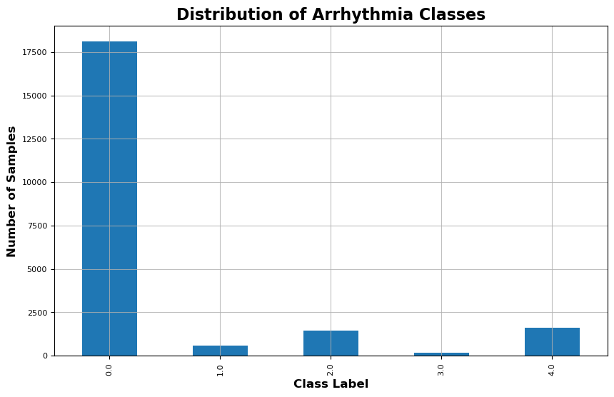

```python
# Plot how many of each class (beat type)
y.value_counts().sort_index().plot(kind='bar')
plt.title("Distribution of Arrhythmia Classes")
plt.xlabel("Class Label")
plt.ylabel("Number of Samples")
plt.grid(True)
plt.show()
```

Visualize Sample Heartbeats

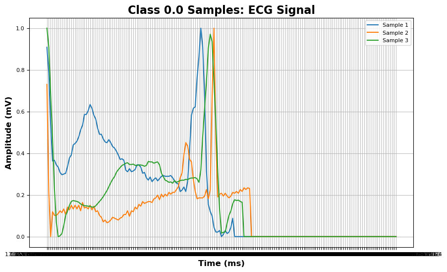

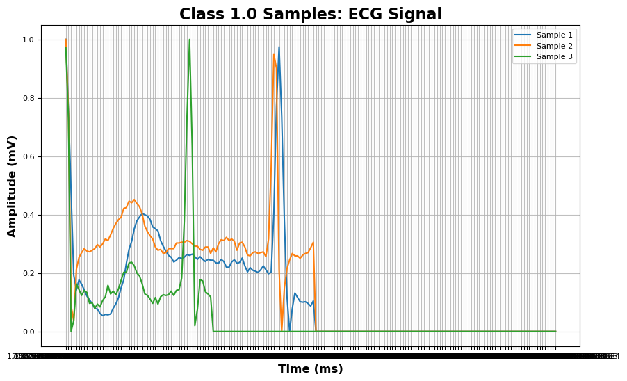

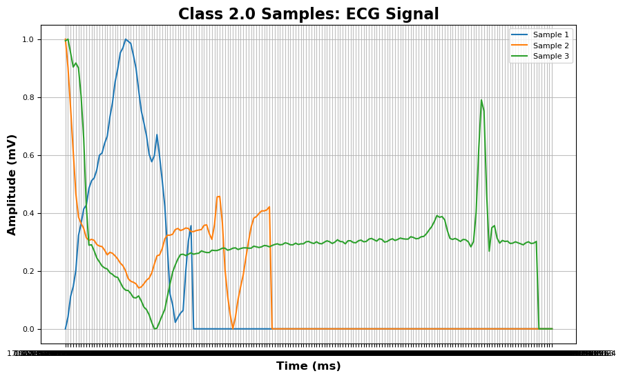

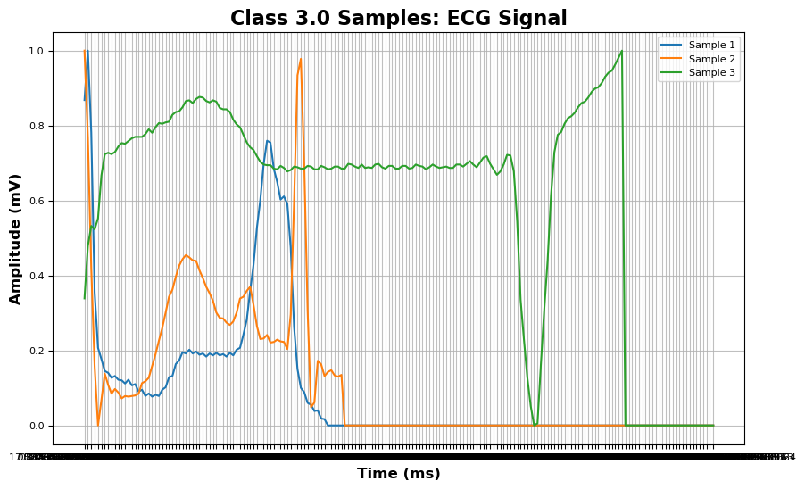

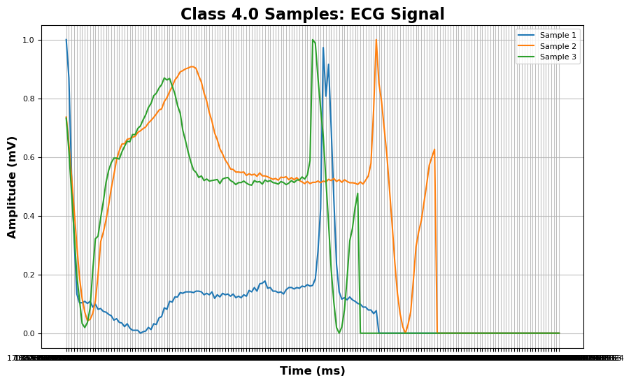

```python
# Get unique class labels
classes = y.unique()

# Plot samples from each class
for class_label in classes:
    class_samples = X[y == class_label]
    plt.figure()
    for i in range(min(3, len(class_samples))):  # Plot up to 3 samples per class
        plt.plot(class_samples.iloc[i], label=f"Sample {i+1}")
    plt.title(f"Class {class_label} Samples: ECG Signal")
    plt.xlabel("Time (ms)")
    plt.ylabel("Amplitude (mV)")
    plt.grid(True)
    plt.legend()
    plt.show()
```

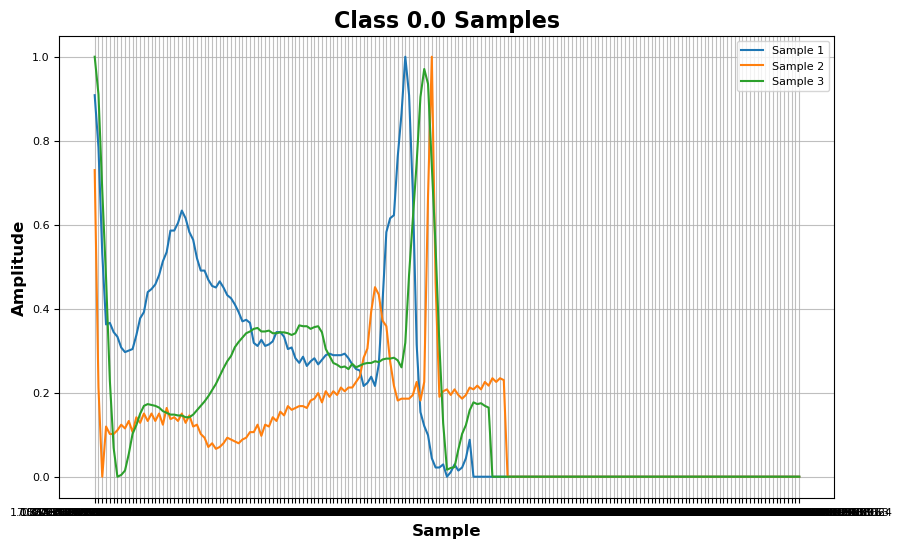

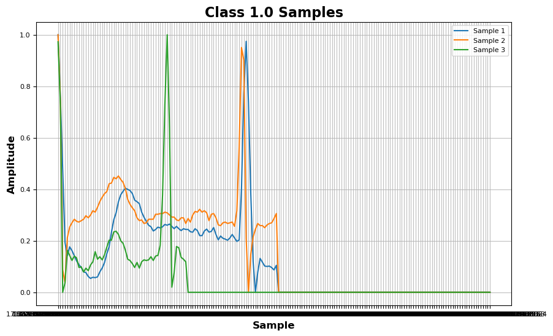

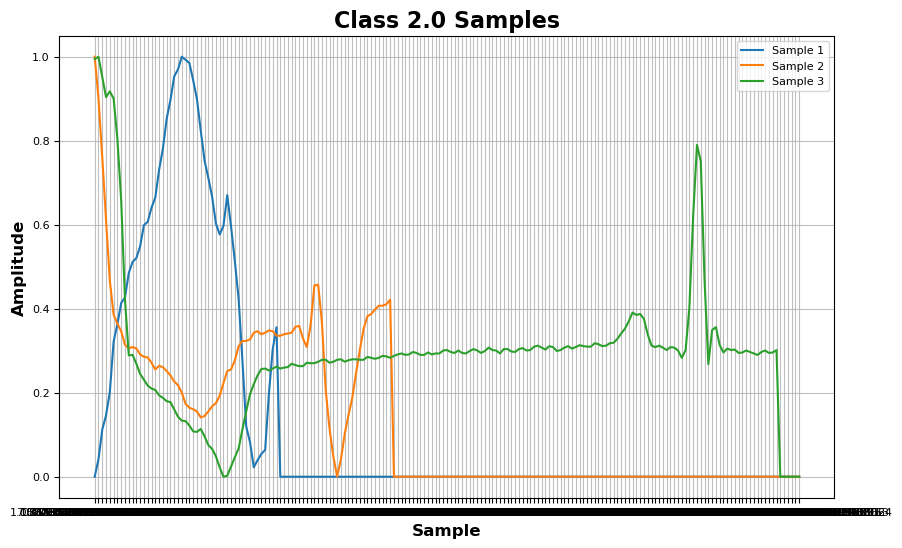

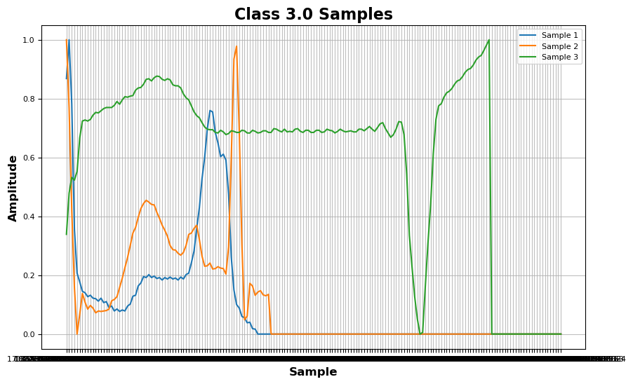

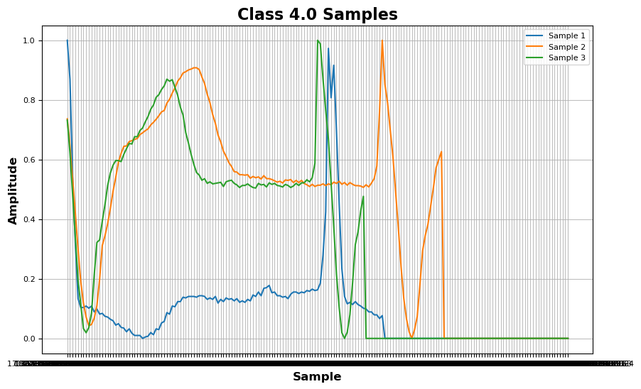

```python
# Get unique class labels
classes = y.unique()

# Plot samples from each class
for class_label in classes:
    class_samples = X[y == class_label]
    plt.figure()
    for i in range(min(3, len(class_samples))):  # Plot up to 3 samples per class
        plt.plot(class_samples.iloc[i], label=f"Sample {i+1}")
    plt.title(f"Class {class_label} Samples")
    plt.xlabel("Sample")
    plt.ylabel("Amplitude")
    plt.grid(True)
    plt.legend()
    plt.show()
```

DATA PREPROCCESSING AND NOISE MODELING

**Clean Signal Preparation**

Select High-Quality ECG Segments (Label = 0)

```python
# Split features (X) and labels (y)
X = df.iloc[:, :-1]
y = df.iloc[:, -1]

# Select only normal (label 0) signals
clean_beats = X[y == 0]
print("Total normal beats:", len(clean_beats))

# Select 25 random clean samples
clean_subset = clean_beats.sample(n=25, random_state=42).reset_index(drop=True)
```

```
Total normal beats: 18117
```

Note: In raw ECG, 10 seconds = 3600 samples (if 360Hz), but my csv uses heartbeat-level segments (187 samples). So: Each row is already a windowed segment (1 heartbeat) We treat each row as a “mini window”, not a 10-second strip No extra slicing is needed here since the dataset is already windowed

Implement Signal Segmentation

```python
# Spliting signals into non-overlapping windows
def segment_signal(signal, window_size):
    """Split long signal into non-overlapping windows."""
    return [signal[i:i + window_size] for i in range(0, len(signal), window_size) if len(signal[i:i + window_size]) == window_size]
```

Create Baseline ECG Signal Repository

```python
# Save original clean samples as baseline
clean_subset.to_csv("ecg_project/data/processed/clean_baseline_signals.csv", index=False)
```

```python
df1 = pd.read_csv("ecg_project/data/processed/clean_baseline_signals.csv")
df1
```

|  | 1.000000000000000000e+00 | 7.582644820213317871e-01 | 1.115702465176582336e-01 | 0.000000000000000000e+00 | 8.057851344347000122e-02 | 7.851240038871765137e-02 | 6.611569970846176147e-02 | 4.958677664399147034e-02 | 4.752065986394882202e-02 | 3.512396663427352905e-02 | ... | 0.000000000000000000e+00.55 | 0.000000000000000000e+00.56 | 0.000000000000000000e+00.57 | 0.000000000000000000e+00.58 | 0.000000000000000000e+00.59 | 0.000000000000000000e+00.60 | 0.000000000000000000e+00.61 | 0.000000000000000000e+00.62 | 0.000000000000000000e+00.63 | 0.000000000000000000e+00.64 |
| --- | --- | --- | --- | --- | --- | --- | --- | --- | --- | --- | --- | --- | --- | --- | --- | --- | --- | --- | --- | --- | --- |
| 0 | 0.967089 | 0.686076 | 0.230380 | 0.053165 | 0.083544 | 0.050633 | 0.017722 | 0.037975 | 0.035443 | 0.010127 | ... | 0.000000 | 0.000 | 0.000000 | 0.000000 | 0.000000 | 0.00 | 0.000000 | 0.00 | 0.000000 | 0.00 |
| 1 | 0.375000 | 0.017241 | 0.211207 | 0.340517 | 0.439655 | 0.504310 | 0.495690 | 0.487069 | 0.504310 | 0.530172 | ... | 0.000000 | 0.000 | 0.000000 | 0.000000 | 0.000000 | 0.00 | 0.000000 | 0.00 | 0.000000 | 0.00 |
| 2 | 0.944079 | 0.825658 | 0.453947 | 0.180921 | 0.078947 | 0.069079 | 0.055921 | 0.042763 | 0.032895 | 0.032895 | ... | 0.000000 | 0.000 | 0.000000 | 0.000000 | 0.000000 | 0.00 | 0.000000 | 0.00 | 0.000000 | 0.00 |
| 3 | 1.000000 | 0.873016 | 0.619048 | 0.243386 | 0.179894 | 0.153439 | 0.132275 | 0.126984 | 0.100529 | 0.111111 | ... | 0.000000 | 0.000 | 0.000000 | 0.000000 | 0.000000 | 0.00 | 0.000000 | 0.00 | 0.000000 | 0.00 |
| 4 | 1.000000 | 0.888651 | 0.683084 | 0.627409 | 0.620985 | 0.629550 | 0.618844 | 0.625268 | 0.625268 | 0.638116 | ... | 0.000000 | 0.000 | 0.000000 | 0.000000 | 0.000000 | 0.00 | 0.000000 | 0.00 | 0.000000 | 0.00 |
| 5 | 0.998529 | 0.852941 | 0.380882 | 0.135294 | 0.179412 | 0.200000 | 0.182353 | 0.175000 | 0.167647 | 0.163235 | ... | 0.000000 | 0.000 | 0.000000 | 0.000000 | 0.000000 | 0.00 | 0.000000 | 0.00 | 0.000000 | 0.00 |
| 6 | 0.907216 | 0.821306 | 0.522337 | 0.209622 | 0.116838 | 0.089347 | 0.065292 | 0.054983 | 0.048110 | 0.044674 | ... | 0.000000 | 0.000 | 0.000000 | 0.000000 | 0.000000 | 0.00 | 0.000000 | 0.00 | 0.000000 | 0.00 |
| 7 | 1.000000 | 0.874459 | 0.378788 | 0.000000 | 0.095238 | 0.277056 | 0.370130 | 0.400433 | 0.409091 | 0.413420 | ... | 0.000000 | 0.000 | 0.000000 | 0.000000 | 0.000000 | 0.00 | 0.000000 | 0.00 | 0.000000 | 0.00 |
| 8 | 0.485114 | 0.401051 | 0.295972 | 0.239930 | 0.243433 | 0.232925 | 0.232925 | 0.231173 | 0.243433 | 0.239930 | ... | 0.000000 | 0.000 | 0.000000 | 0.000000 | 0.000000 | 0.00 | 0.000000 | 0.00 | 0.000000 | 0.00 |
| 9 | 0.920354 | 0.734513 | 0.457649 | 0.213654 | 0.113780 | 0.187105 | 0.225032 | 0.199747 | 0.184576 | 0.184576 | ... | 0.000000 | 0.000 | 0.000000 | 0.000000 | 0.000000 | 0.00 | 0.000000 | 0.00 | 0.000000 | 0.00 |
| 10 | 1.000000 | 0.816667 | 0.300000 | 0.000000 | 0.088333 | 0.190000 | 0.236667 | 0.280000 | 0.285000 | 0.280000 | ... | 0.311667 | 0.315 | 0.316667 | 0.311667 | 0.301667 | 0.32 | 0.318333 | 0.31 | 0.311667 | 0.32 |
| 11 | 0.968421 | 0.945263 | 0.395789 | 0.000000 | 0.210526 | 0.353684 | 0.290526 | 0.273684 | 0.307368 | 0.305263 | ... | 0.000000 | 0.000 | 0.000000 | 0.000000 | 0.000000 | 0.00 | 0.000000 | 0.00 | 0.000000 | 0.00 |
| 12 | 0.041298 | 0.126844 | 0.268437 | 0.395280 | 0.495575 | 0.581121 | 0.678466 | 0.755162 | 0.775811 | 0.772861 | ... | 0.000000 | 0.000 | 0.000000 | 0.000000 | 0.000000 | 0.00 | 0.000000 | 0.00 | 0.000000 | 0.00 |
| 13 | 1.000000 | 0.952261 | 0.766332 | 0.306533 | 0.130653 | 0.180905 | 0.155779 | 0.097990 | 0.080402 | 0.090452 | ... | 0.000000 | 0.000 | 0.000000 | 0.000000 | 0.000000 | 0.00 | 0.000000 | 0.00 | 0.000000 | 0.00 |
| 14 | 0.972131 | 0.891803 | 0.570492 | 0.222951 | 0.186885 | 0.206557 | 0.190164 | 0.177049 | 0.170492 | 0.163934 | ... | 0.000000 | 0.000 | 0.000000 | 0.000000 | 0.000000 | 0.00 | 0.000000 | 0.00 | 0.000000 | 0.00 |
| 15 | 0.554795 | 0.965753 | 0.849315 | 0.164384 | 0.246575 | 0.541096 | 0.691781 | 0.664384 | 0.712329 | 0.691781 | ... | 0.000000 | 0.000 | 0.000000 | 0.000000 | 0.000000 | 0.00 | 0.000000 | 0.00 | 0.000000 | 0.00 |
| 16 | 0.958194 | 0.983278 | 0.392977 | 0.000000 | 0.222408 | 0.362876 | 0.332776 | 0.307692 | 0.316054 | 0.324415 | ... | 0.000000 | 0.000 | 0.000000 | 0.000000 | 0.000000 | 0.00 | 0.000000 | 0.00 | 0.000000 | 0.00 |
| 17 | 0.892086 | 0.679856 | 0.338129 | 0.000000 | 0.046763 | 0.057554 | 0.089928 | 0.154676 | 0.172662 | 0.187050 | ... | 0.000000 | 0.000 | 0.000000 | 0.000000 | 0.000000 | 0.00 | 0.000000 | 0.00 | 0.000000 | 0.00 |
| 18 | 0.966814 | 0.831858 | 0.575221 | 0.329646 | 0.108407 | 0.013274 | 0.002212 | 0.022124 | 0.039823 | 0.055310 | ... | 0.000000 | 0.000 | 0.000000 | 0.000000 | 0.000000 | 0.00 | 0.000000 | 0.00 | 0.000000 | 0.00 |
| 19 | 1.000000 | 0.843612 | 0.400881 | 0.226872 | 0.281938 | 0.270925 | 0.240088 | 0.244493 | 0.233480 | 0.231278 | ... | 0.000000 | 0.000 | 0.000000 | 0.000000 | 0.000000 | 0.00 | 0.000000 | 0.00 | 0.000000 | 0.00 |
| 20 | 0.997836 | 0.904762 | 0.554113 | 0.266234 | 0.207792 | 0.181818 | 0.145022 | 0.132035 | 0.125541 | 0.112554 | ... | 0.000000 | 0.000 | 0.000000 | 0.000000 | 0.000000 | 0.00 | 0.000000 | 0.00 | 0.000000 | 0.00 |
| 21 | 0.950739 | 0.916256 | 0.310345 | 0.000000 | 0.218391 | 0.325123 | 0.293924 | 0.282430 | 0.287356 | 0.285714 | ... | 0.000000 | 0.000 | 0.000000 | 0.000000 | 0.000000 | 0.00 | 0.000000 | 0.00 | 0.000000 | 0.00 |
| 22 | 0.016807 | 0.109244 | 0.263305 | 0.411765 | 0.512605 | 0.593838 | 0.725490 | 0.767507 | 0.773109 | 0.773109 | ... | 0.000000 | 0.000 | 0.000000 | 0.000000 | 0.000000 | 0.00 | 0.000000 | 0.00 | 0.000000 | 0.00 |
| 23 | 0.972705 | 0.967742 | 0.732010 | 0.240695 | 0.099256 | 0.183623 | 0.121588 | 0.039702 | 0.034739 | 0.032258 | ... | 0.000000 | 0.000 | 0.000000 | 0.000000 | 0.000000 | 0.00 | 0.000000 | 0.00 | 0.000000 | 0.00 |
| 24 | 1.000000 | 0.766667 | 0.297436 | 0.102564 | 0.084615 | 0.074359 | 0.033333 | 0.033333 | 0.043590 | 0.028205 | ... | 0.000000 | 0.000 | 0.000000 | 0.000000 | 0.000000 | 0.00 | 0.000000 | 0.00 | 0.000000 | 0.00 |

25 rows × 187 columns

```python
# Min-Max Normalization
normalized_clean = (clean_subset - clean_subset.min()) / (clean_subset.max() - clean_subset.min())

# Save normalized data
normalized_clean.to_csv("ecg_project/data/processed/clean_baseline_signals_normalized.csv", index=False)
```

Save Preprocessed Clean Signals in Standard Format

```python
# Save as NumPy array
np.save("ecg_project/data/processed/clean_baseline_signals.npy", normalized_clean.to_numpy())

print('Successfully saved!')
```

```
Successfully saved!
```

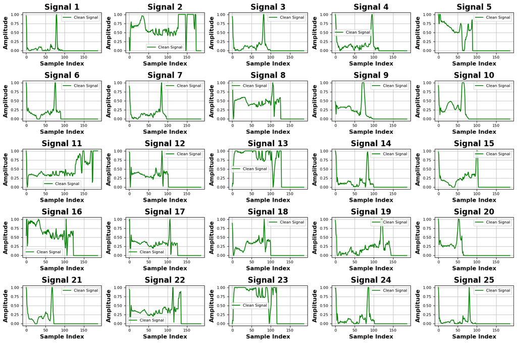

```python
# Number of signals
num_signals = len(clean_ecgs)

# Calculate the number of rows and columns for subplots
num_rows = int(np.ceil(np.sqrt(num_signals)))
num_cols = int(np.ceil(num_signals / num_rows))

# Create a figure with subplots
fig, axs = plt.subplots(num_rows, num_cols, figsize=(15, 10))

# Loop through each signal and plot it
for i in range(num_signals):
    row = i // num_cols
    col = i % num_cols
    axs[row, col].plot(clean_ecgs[i], label='Clean Signal', color='green')
    axs[row, col].set_title(f"Signal {i+1}")
    axs[row, col].set_xlabel("Sample Index")
    axs[row, col].set_ylabel("Amplitude")
    axs[row, col].legend()
    axs[row, col].grid(True)

# Hide any unused subplots
for i in range(num_signals, num_rows * num_cols):
    row = i // num_cols
    col = i % num_cols
    axs[row, col].axis('off')

# Layout so plots do not overlap
fig.tight_layout()

# Show the plot
plt.show()
```

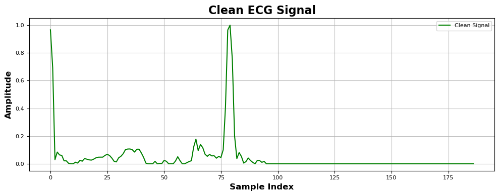

```python
# Visualize Clean Signal
i = 0  # Index of signal to visualize
plt.figure(figsize=(10, 4))
plt.plot(clean_ecgs[i], label='Clean Signal', color='green')
plt.title("Clean ECG Signal")
plt.xlabel("Sample Index")
plt.ylabel("Amplitude")
plt.legend()
plt.grid(True)
plt.tight_layout()
plt.show()
```

NOISE SYNTHESIS AND CONTAMINATION

```python
# Load clean, normalized ECGs
clean_ecgs = pd.read_csv("ecg_project/data/processed/clean_baseline_signals_normalized.csv").to_numpy()

print('Loaded!')


# Power Line Interference (50/60 Hz Sinusoidal)
def add_powerline_noise(signal, fs=360, freq=50, amplitude=0.1):
    t = np.linspace(0, len(signal)/fs, len(signal))
    noise = amplitude * np.sin(2 * np.pi * freq * t)
    return signal + noise
print('PLI_noise aded!')
```

```
Loaded!
PLI_noise aded!
```

```python
#Muscle Artifact Noise (High-Frequency Random)
def add_muscle_noise(signal, strength=0.1):
    noise = strength * np.random.normal(0, 1, len(signal))
    return signal + noise
```

```python
# Baseline Wander (Low-Frequency Polynomial Drift)
def add_baseline_wander(signal, fs=360, freq=0.5, amplitude=0.1):
    t = np.linspace(0, len(signal)/fs, len(signal))
    drift = amplitude * np.sin(2 * np.pi * freq * t)
    return signal + drift
```

```python
# Electrode Motion Artifact (Sudden Amplitude Jumps)
def add_electrode_artifact(signal, jump_size=0.3, jump_chance=0.01):
    artifact = signal.copy()
    for i in range(len(artifact)):
        if np.random.rand() < jump_chance:
            artifact[i:] += jump_size * (2 * np.random.rand() - 1)  # sudden shift
    return artifact
```

```python
# Add Noise with Controllable SNR (5dB, 10dB, 15dB)
def add_noise_with_snr(signal, snr_db):
    signal_power = np.mean(signal**2)
    snr_linear = 10**(snr_db / 10)
    noise_power = signal_power / snr_linear
    noise = np.random.normal(0, np.sqrt(noise_power), len(signal))
    return signal + noise
```

```python
# Generate Noisy ECG Dataset (All Noises Combined)
noisy_ecgs = []

for signal in clean_ecgs:
    # Apply all noise types + control SNR
    noisy = signal
    noisy = add_powerline_noise(noisy, freq=50)
    noisy = add_muscle_noise(noisy, strength=0.05)
    noisy = add_baseline_wander(noisy, freq=0.5)
    noisy = add_electrode_artifact(noisy, jump_size=0.2)
    noisy = add_noise_with_snr(noisy, snr_db=10)
    noisy_ecgs.append(noisy)

noisy_ecgs = np.array(noisy_ecgs)

# Save Noisy ECG Data
# Save to CSV
pd.DataFrame(noisy_ecgs).to_csv("ecg_project/data/processed/noisy_ecgs_snr10.csv", index=False)

# Also save as NumPy array
np.save("ecg_project/data/processed/noisy_ecgs_snr10.npy", noisy_ecgs)
```

```python
df5 = pd.read_csv("ecg_project/data/processed/noisy_ecgs_snr10.csv")
df5
```

|  | 0 | 1 | 2 | 3 | 4 | 5 | 6 | 7 | 8 | 9 | ... | 177 | 178 | 179 | 180 | 181 | 182 | 183 | 184 | 185 | 186 |
| --- | --- | --- | --- | --- | --- | --- | --- | --- | --- | --- | --- | --- | --- | --- | --- | --- | --- | --- | --- | --- | --- |
| 0 | 1.181757 | 0.838715 | 0.163480 | 0.024267 | 0.071915 | -0.073875 | -0.135594 | 0.094821 | 0.045737 | 0.166458 | ... | -0.306510 | -0.111583 | -0.200077 | -0.057372 | -0.028126 | -0.003278 | -0.112649 | -0.170180 | -0.148416 | -0.059042 |
| 1 | 0.288569 | 0.061593 | 0.106466 | 0.609099 | 0.801195 | 0.966194 | 0.754211 | 0.261558 | 0.333020 | 0.932643 | ... | 0.162880 | -0.010709 | -0.233962 | -0.105225 | 0.177316 | 0.168855 | -0.484819 | -0.047123 | -0.353439 | -0.467254 |
| 2 | 0.946462 | 0.854008 | 0.329415 | 0.338773 | 0.044373 | -0.049716 | 0.150689 | 0.140219 | 0.116345 | 0.218604 | ... | -0.389522 | -0.177177 | -0.184733 | -0.021916 | -0.109329 | -0.104731 | -0.123385 | -0.233207 | -0.132114 | -0.172741 |
| 3 | 0.871264 | 0.983658 | 0.747802 | 0.465604 | -0.025130 | 0.112054 | 0.172761 | 0.268166 | 0.038628 | 0.322122 | ... | 0.059400 | -0.235338 | -0.001901 | -0.290257 | 0.010073 | -0.060736 | -0.206208 | -0.147172 | -0.212164 | -0.202078 |
| 4 | 1.056168 | 1.166075 | 0.825102 | 0.972838 | 1.105966 | 1.036675 | 0.565804 | 0.693250 | 0.701606 | 1.013036 | ... | -0.135122 | -0.174829 | -0.195358 | 0.347192 | 0.044519 | -0.000736 | 0.170515 | -0.003715 | -0.100866 | 0.070903 |
| 5 | 0.947371 | 1.073091 | 0.190369 | 0.337727 | 0.004837 | 0.363963 | 0.392961 | 0.188938 | 0.290099 | 0.229729 | ... | -0.150137 | 0.002003 | 0.153527 | -0.036631 | -0.018137 | 0.057341 | -0.225456 | -0.234186 | -0.036991 | 0.241118 |
| 6 | 1.000408 | 0.986882 | 0.440591 | 0.484886 | 0.104158 | -0.050074 | -0.026202 | 0.500254 | -0.015321 | 0.084356 | ... | -0.053341 | 0.301073 | 0.181538 | 0.201452 | 0.376642 | 0.405851 | 0.292121 | 0.038846 | -0.023448 | 0.160386 |
| 7 | 1.155746 | 0.895082 | 0.163590 | 0.057275 | -0.343686 | 0.503308 | 0.144192 | 0.708135 | 0.797835 | 0.452690 | ... | -0.083250 | -0.097855 | -0.076282 | -0.173189 | -0.067973 | -0.028969 | -0.100628 | -0.418032 | -0.259822 | -0.342976 |
| 8 | 0.393401 | 0.571771 | -0.015220 | 0.353199 | 0.308382 | 0.436111 | 0.296097 | 0.123431 | 0.323602 | 0.608659 | ... | -0.125468 | -0.021055 | 0.036927 | 0.111494 | 0.147413 | 0.064775 | -0.028327 | -0.095877 | -0.123574 | 0.086238 |
| 9 | 0.894558 | 0.793607 | 0.330695 | 0.254307 | 0.198302 | 0.250538 | 0.094916 | 0.212580 | 0.114122 | 0.392720 | ... | -0.133540 | 0.108957 | 0.363342 | 0.218440 | 0.219902 | 0.003040 | 0.117945 | 0.114970 | 0.116722 | 0.019268 |
| 10 | 0.745258 | 0.987350 | 0.418233 | 0.685190 | 0.048400 | 0.561188 | -0.007961 | 0.434233 | 0.084624 | 0.219261 | ... | 0.961183 | 1.206423 | 1.312975 | 1.215310 | 1.198148 | 1.229615 | 0.685577 | 1.120307 | 0.862128 | 0.833213 |
| 11 | 1.097382 | 1.101421 | 0.578283 | 0.171558 | 0.348801 | 0.386566 | 0.172613 | 0.355587 | 0.278789 | 0.593493 | ... | 0.312600 | 0.070690 | 0.025924 | 0.001372 | 0.319591 | 0.321725 | 0.102082 | -0.014768 | 0.117683 | 0.186604 |
| 12 | -0.134810 | 0.098462 | 0.022425 | 0.603767 | 0.756880 | 0.494807 | 0.659461 | 0.976154 | 1.435224 | 1.100228 | ... | -0.018486 | -0.490841 | -0.093345 | -0.078843 | 0.225174 | 0.420066 | -0.347297 | -0.553130 | -0.075661 | 0.295561 |
| 13 | 1.030158 | 0.900019 | 0.851972 | 0.732797 | -0.066508 | 0.198567 | 0.116335 | 0.068442 | 0.072846 | 0.063970 | ... | 0.088308 | -0.096569 | 0.076912 | 0.197628 | 0.227204 | 0.158227 | -0.010739 | -0.066771 | -0.190554 | 0.005220 |
| 14 | 0.980937 | 1.154135 | 0.566788 | 0.302955 | 0.201991 | 0.264487 | 0.219932 | 0.101602 | 0.196042 | 0.350250 | ... | 0.063639 | 0.021011 | 0.174963 | -0.018559 | 0.208190 | 0.316654 | 0.159534 | 0.112898 | 0.156943 | 0.212155 |
| 15 | 0.936421 | 1.167956 | 1.049744 | 0.230007 | 0.378940 | 0.703204 | 0.868116 | 0.826952 | 0.883831 | 1.232491 | ... | 0.199245 | -0.254958 | -0.139811 | 0.177080 | 0.217152 | -0.051653 | 0.138667 | 0.118858 | -0.068557 | 0.046671 |
| 16 | 1.188948 | 1.070474 | 0.358112 | 0.050801 | 0.410215 | 0.637918 | 0.297304 | 0.391258 | 0.525133 | 0.367704 | ... | 0.021822 | -0.132325 | -0.070663 | -0.109977 | 0.142661 | -0.198737 | -0.152823 | -0.252031 | -0.119004 | -0.005171 |
| 17 | 0.849501 | 0.724443 | 0.367367 | -0.247996 | 0.009833 | -0.038830 | 0.198301 | 0.114297 | 0.463246 | 0.412430 | ... | 0.106507 | 0.092882 | -0.048299 | 0.362889 | 0.236319 | -0.015497 | 0.273120 | 0.228429 | 0.211998 | 0.324334 |
| 18 | 1.055396 | 0.574791 | 0.702099 | 0.679543 | -0.177061 | -0.067425 | -0.345573 | 0.000126 | 0.309994 | 0.331134 | ... | 0.298361 | 0.076163 | 0.461256 | 0.553507 | 0.221433 | 0.459323 | 0.011014 | 0.165488 | 0.137961 | 0.036045 |
| 19 | 1.104335 | 0.823926 | 0.438093 | 0.501813 | 0.490225 | 0.374538 | 0.304326 | 0.198155 | 0.320778 | 0.542017 | ... | -0.104761 | 0.147595 | 0.088939 | 0.301916 | 0.229579 | 0.147730 | 0.237461 | -0.195348 | 0.049462 | 0.095772 |
| 20 | 1.082421 | 0.813887 | 0.676071 | 0.498222 | 0.108313 | 0.213609 | 0.207510 | 0.170476 | 0.193618 | 0.202636 | ... | 0.061637 | 0.135242 | 0.439181 | 0.388571 | 0.260850 | 0.229815 | 0.018852 | 0.234290 | 0.206718 | 0.181505 |
| 21 | 0.797682 | 0.915597 | 0.188266 | -0.129612 | 0.077394 | 0.273594 | 0.503487 | 0.490553 | 0.253892 | 0.371688 | ... | -0.274342 | -0.241527 | -0.147050 | 0.099000 | -0.119337 | -0.501825 | -0.352754 | -0.213625 | -0.226825 | -0.034862 |
| 22 | 0.546902 | 0.488200 | 0.206552 | 0.466920 | 0.786616 | 0.504056 | 0.719838 | 0.637310 | 1.002878 | 0.901904 | ... | -0.298023 | -0.321870 | -0.152539 | -0.438436 | 0.162717 | 0.070181 | -0.010154 | -0.330128 | -0.269295 | 0.238169 |
| 23 | 0.972584 | 1.117078 | 1.125508 | 0.324017 | -0.115263 | 0.240306 | 0.144551 | 0.066211 | 0.025304 | 0.310810 | ... | 0.146864 | 0.262555 | -0.044791 | 0.232619 | 0.083705 | 0.056284 | 0.339265 | 0.108513 | -0.044708 | 0.084087 |
| 24 | 0.874156 | 0.737884 | 0.139729 | 0.156350 | 0.017599 | 0.051754 | 0.069057 | -0.100851 | -0.002662 | 0.086865 | ... | 0.088117 | 0.060093 | 0.137390 | 0.118001 | 0.074077 | 0.166620 | 0.096590 | 0.101070 | -0.046318 | -0.061444 |

25 rows × 187 columns

```python
df5.info()
```

```
<class 'pandas.core.frame.DataFrame'>
RangeIndex: 25 entries, 0 to 24
Columns: 187 entries, 0 to 186
dtypes: float64(187)
memory usage: 36.7 KB
```

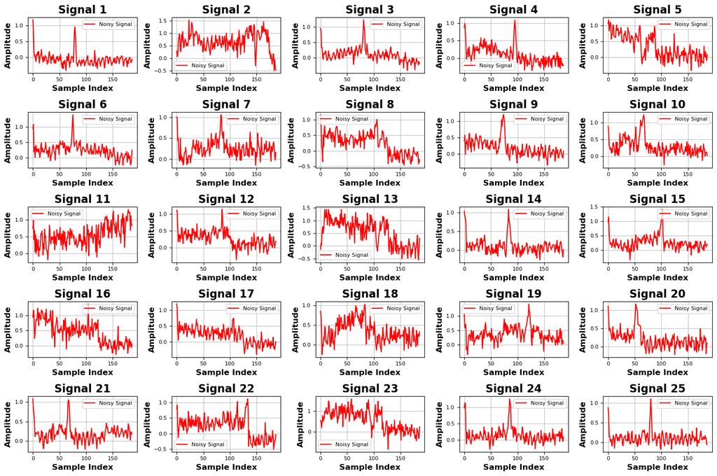

```python
# Number of signals
num_signals = len(noisy_ecgs)

# Calculate the number of rows and columns for subplots
num_rows = int(np.ceil(np.sqrt(num_signals)))
num_cols = int(np.ceil(num_signals / num_rows))

# Create a figure with subplots
fig, axs = plt.subplots(num_rows, num_cols, figsize=(15, 10))

# Loop through each signal and plot it
for i in range(num_signals):
    row = i // num_cols
    col = i % num_cols
    axs[row, col].plot(noisy_ecgs[i], label='Noisy Signal', color='red')
    axs[row, col].set_title(f"Signal {i+1}")
    axs[row, col].set_xlabel("Sample Index")
    axs[row, col].set_ylabel("Amplitude")
    axs[row, col].legend()
    axs[row, col].grid(True)

# Hide any unused subplots
for i in range(num_signals, num_rows * num_cols):
    row = i // num_cols
    col = i % num_cols
    axs[row, col].axis('off')

# Layout so plots do not overlap
fig.tight_layout()

# Show the plot
plt.show()
```

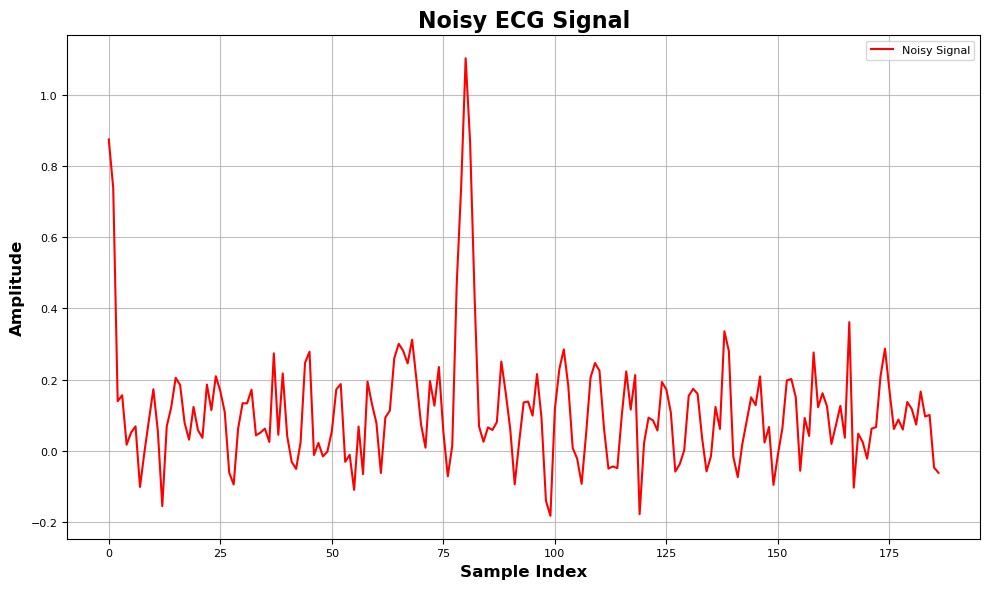

```python
# Visualize Noisy Signal
plt.plot(noisy_ecgs[i], label='Noisy Signal', color='red')
plt.title("Noisy ECG Signal")
plt.xlabel("Sample Index")
plt.ylabel("Amplitude")
plt.legend()
plt.grid(True)
plt.tight_layout()
plt.show()
```

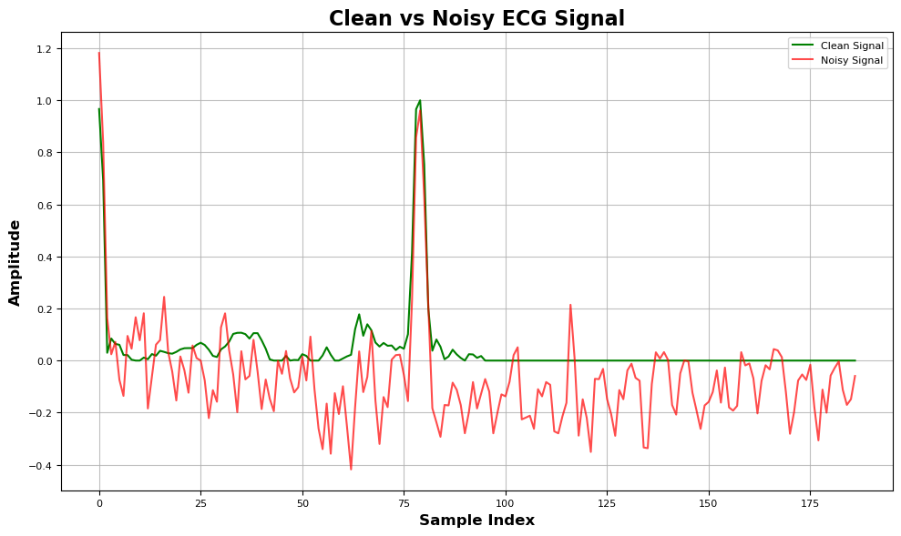

```python
# Visualize a Clean vs Noisy Example
i = 0  # Index of signal to visualize
plt.plot(clean_ecgs[i], label='Clean Signal', color='green')
plt.plot(noisy_ecgs[i], label='Noisy Signal', color='red', alpha=0.7)
plt.title("Clean vs Noisy ECG Signal")
plt.xlabel("Sample Index")
plt.ylabel("Amplitude")
plt.tight_layout()
plt.legend()
plt.show()
```

DATASET SPLITTING AND VALIDATION SET_UP

```python
df_mitbih = df.iloc[:17000].copy()
df_ptb = df.iloc[17000:].copy()  # For external validation
```

Split MIT-BIH into Train, Validation, and Test

```python
# Features and labels
X = df_mitbih.iloc[:, :-1]
y = df_mitbih.iloc[:, -1]

# Train (70%) and temp (30%)
X_train, X_temp, y_train, y_temp = train_test_split(X, y, test_size=0.30, stratify=y, random_state=42)

# Temp split into validation (15%) and test (15%)
X_val, X_test, y_val, y_test = train_test_split(X_temp, y_temp, test_size=0.50, stratify=y_temp, random_state=42)
```

Create data loaders and batch processing functions

```python
# Build PyTorch DataLoaders
class HeartbeatDataset(Dataset):
    def __init__(self, X, y):
        self.X = torch.tensor(X.values, dtype=torch.float32)
        self.y = torch.tensor(y.values, dtype=torch.long)

    def __len__(self):
        return len(self.X)

    def __getitem__(self, idx):
        return self.X[idx], self.y[idx]

# Wrap datasets
train_dataset = HeartbeatDataset(X_train, y_train)
val_dataset = HeartbeatDataset(X_val, y_val)
test_dataset = HeartbeatDataset(X_test, y_test)
ptb_dataset = HeartbeatDataset(df_ptb.iloc[:, :-1], df_ptb.iloc[:, -1])

# Loaders
batch_size = 64

train_loader = DataLoader(train_dataset, batch_size=batch_size, shuffle=True)
val_loader = DataLoader(val_dataset, batch_size=batch_size, shuffle=False)
test_loader = DataLoader(test_dataset, batch_size=batch_size, shuffle=False)
ptb_loader = DataLoader(ptb_dataset, batch_size=batch_size, shuffle=False)
print('Done')
```

```
Done
```

```python
# Save Splits for Reproducibility
X_train.assign(label=y_train).to_csv("mitbih_train.csv", index=False)
X_val.assign(label=y_val).to_csv("mitbih_val.csv", index=False)
X_test.assign(label=y_test).to_csv("mitbih_test.csv", index=False)
df_ptb.to_csv("ptb_external_validation.csv", index=False)
```

DENOISING METHOD IMPLEMENTATION

**1. Classical Signal Processing Methods**

```python
# Butterworth filter builder
def build_filter(order, cutoff, btype='low'):
    b, a = butter(order, cutoff, btype=btype, analog=False)
    return b, a

# Zero-phase Butterworth filtering (forward-backward)
def apply_filter(signal, order, cutoff, btype='low'):
    b, a = build_filter(order, cutoff, btype)
    return filtfilt(b, a, signal)
```

Design Low-pass, High-pass, and Band-pass Filters

```python
# Filter parameters
order = 4

# LOW-PASS: keep low-frequency info
low_cutoff = 0.1

# HIGH-PASS: remove baseline wander
high_cutoff = 0.01

# BAND-PASS: focus on mid-band frequencies
band_cutoff = [0.01, 0.2]
```

```python
# Applied Butterworth filter
signal_b = noisy_ecgs
filtered_low = apply_filter(noisy_ecgs, order, low_cutoff, btype='low')
filtered_high = apply_filter(noisy_ecgs, order, high_cutoff, btype='high')
filtered_band = apply_filter(noisy_ecgs, order, band_cutoff, btype='band')
```

```python
df4 = pd.DataFrame({
    'filtered_low': apply_filter(noisy_ecgs, order, low_cutoff, btype='low').flatten(),
    'filtered_high': apply_filter(noisy_ecgs, order, high_cutoff, btype='high').flatten(),
    'filtered_band': apply_filter(noisy_ecgs, order, band_cutoff, btype='band').flatten()
})

df4.to_csv('filtered_bw_signals.csv', index=False)
print('saved!')
df4 = pd.read_csv('filtered_bw_signals.csv')
df4
```

```
saved!
```

|  | filtered_low | filtered_high | filtered_band |
| --- | --- | --- | --- |
| 0 | 1.179100 | 0.043303 | -0.041022 |
| 1 | 0.952742 | -0.275616 | -0.420546 |
| 2 | 0.735545 | -0.926724 | -0.750775 |
| 3 | 0.535419 | -1.041812 | -0.994488 |
| 4 | 0.358828 | -0.970055 | -1.134778 |
| ... | ... | ... | ... |
| 4670 | 0.065611 | 0.182102 | 0.119380 |
| 4671 | 0.037713 | 0.118785 | 0.105056 |
| 4672 | 0.006626 | 0.130217 | 0.074519 |
| 4673 | -0.026505 | -0.009980 | 0.029533 |
| 4674 | -0.060395 | -0.017672 | -0.023861 |

4675 rows × 3 columns

Example application on a single sample:

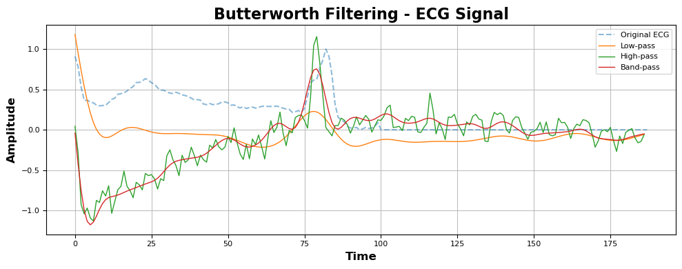

```python
signal_b = noisy_ecgs[0]
filtered_low = apply_filter(noisy_ecgs[0], order, low_cutoff, btype='low')
filtered_high = apply_filter(noisy_ecgs[0], order, high_cutoff, btype='high')
filtered_band = apply_filter(noisy_ecgs[0], order, band_cutoff, btype='band')

# Compare Filter Characteristics with Visualization
plt.figure(figsize=(10, 4))
plt.plot(ecg_signal, label='Original ECG', linestyle='--', alpha=0.5)
plt.plot(filtered_low, label="Low-pass", linewidth=1)
plt.plot(filtered_high, label="High-pass", linewidth=1)
plt.plot(filtered_band, label="Band-pass", linewidth=1)
plt.title("Butterworth Filtering - ECG Signal")
plt.legend()
plt.xlabel("Time")
plt.ylabel("Amplitude")
plt.grid(True)
plt.tight_layout()
plt.show()
```

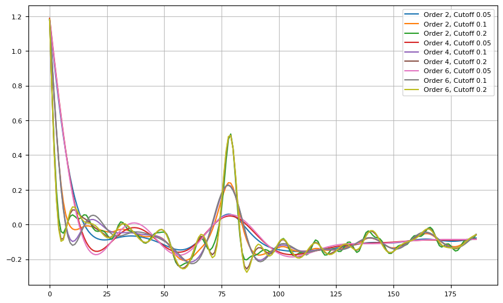

```python
# Create parameter optimization functions for cutoff frequencies
orders = [2, 4, 6]
cutoffs = [0.05, 0.1, 0.2]

for o in orders:
    for c in cutoffs:
        filtered = apply_filter(noisy_ecgs, o, c, btype='low')
        plt.plot(filtered[0], label=f"Order {o}, Cutoff {c}")
        plt.legend()
```

Wavelet Denoising Implementation:

```python
# Extract only the signal values (assuming no label in this version)
Noisy_ecgs = df.iloc[:, :].copy()
```

Wavelet Denoising Function

```python
def wavelet_denoise(noisy_ecgs, wavelet='db6', level=3, thresholding='soft'):
    # Decompose the signal
    coeffs = pywt.wavedec(Noisy_ecgs, wavelet, level=level)

    # Estimate noise level (universal threshold)
    sigma = np.median(np.abs(coeffs[-1])) / 0.6745
    uthresh = sigma * np.sqrt(2 * np.log(len(Noisy_ecgs)))

    # Threshold detail coefficients
    coeffs_thresh = [coeffs[0]]  # Keep approximation untouched
    for detail in coeffs[1:]:
        coeffs_thresh.append(pywt.threshold(detail, value=uthresh, mode=thresholding))

    # Reconstruct signal
    denoised = pywt.waverec(coeffs_thresh, wavelet)

    # Ensure correct length
    return denoised[:len(noisy_ecgs)]
```

```python
# Apply wavelet denoising row-wise
def apply_wavelet_denoising(noisy_ecgs):
    coeffs = pywt.wavedec(noisy_ecgs, 'db4', level=3)
    coeffs[-1] = np.zeros_like(coeffs[-1])
    coeffs[-2] = np.zeros_like(coeffs[-2])
    denoised_coeffs = coeffs
    reconstructed_signal = pywt.waverec(denoised_coeffs, 'db4')
    return reconstructed_signal[:len(noisy_ecg)]  # Trim to original length

denoised_ecgs_wt = np.apply_along_axis(apply_wavelet_denoising, 0, noisy_ecgs)
```

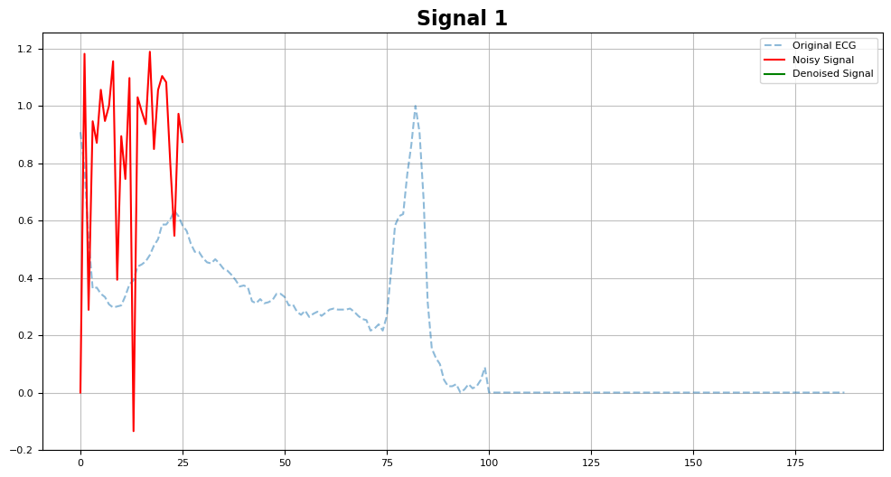

```python
# Visualize Before and After (Sample)
# Plot the original noisy signal and the denoised signal
i = 0
plt.figure(figsize=(12, 6))
plt.plot(ecg_signal, label='Original ECG', linestyle='--', alpha=0.5)
plt.plot(noisy_ecgs[i], label='Noisy Signal', color='red')
plt.plot(denoised_ecgs_wt[i], label='Denoised Signal', color='green')
plt.title(f"Signal {i+1}")
plt.legend()
plt.grid(True)
plt.show()
```

```python
# Save Denoised Dataset
df = pd.DataFrame(denoised_ecgs)
df.to_csv('filtered_wt_signals.csv', index=False)
```

**2. Adaptive Filtering Method**

LMS Adaptive Filter Implementation

```python
# Select a sample signal (first row)
noisy_ecg = df.iloc[0].values  # Noisy ECG signal
```

Generate Reference Noise

N/B: In practice, reference noise is collected from another sensor, but for testing we simulate it:

```python
np.random.seed(0)  # for reproducibility
ref_noise = np.random.normal(0, 0.2, size=len(ecg_signal))  # white Gaussian noise

# Add noise to simulate corrupted ECG
noisy_ecg = ecg_signal + ref_noise
```

```python
# LMS Algorithm
def lms_filter(noisy_ecg, reference, mu, filter_order):
    # Ensure desired and reference are numpy arrays
    noisy_ecg = np.array(noisy_ecg).flatten()
    reference = np.array(reference).flatten()

    # Initialize variables
    e = np.zeros(len(noisy_ecg))
    y = np.zeros(len(noisy_ecg))
    w = np.zeros(filter_order)

    for i in range(filter_order, len(noisy_ecg)):
        x = reference[i-filter_order:i][::-1]
        y[i] = np.dot(w, x)
        e[i] = noisy_ecg[i] - y[i]
        w += 2 * mu * e[i] * x  # Weight update

    return e

# Apply LMS filter to each signal in noisy_ecgs
cleaned_ecgs = []
for signal in noisy_ecgs.T:  # Assuming noisy_ecgs is a 2D array with signals in columns
    cleaned_signal = lms_filter(noisy_ecg, ref_noise, mu=0.01, filter_order=4)
    cleaned_ecgs.append(cleaned_signal)

cleaned_ecgs = np.array(cleaned_ecgs).T


# Save to CSV
df = pd.DataFrame(cleaned_ecgs)
df.to_csv('filtered_lms_signals.csv', index=False)
```

```python
df = pd.read_csv('filtered_lms_signals.csv')
df
```

|  | 0 | 1 | 2 | 3 | 4 | 5 | 6 | 7 | 8 | 9 | ... | 16 | 17 | 18 | 19 | 20 | 21 | 22 | 23 | 24 | 25 |
| --- | --- | --- | --- | --- | --- | --- | --- | --- | --- | --- | --- | --- | --- | --- | --- | --- | --- | --- | --- | --- | --- |
| 0 | 0.000000 | 0.000000 | 0.000000 | 0.000000 | 0.000000 | 0.000000 | 0.000000 | 0.000000 | 0.000000 | 0.000000 | ... | 0.000000 | 0.000000 | 0.000000 | 0.000000 | 0.000000 | 0.000000 | 0.000000 | 0.000000 | 0.000000 | 0.000000 |
| 1 | 0.000000 | 0.000000 | 0.000000 | 0.000000 | 0.000000 | 0.000000 | 0.000000 | 0.000000 | 0.000000 | 0.000000 | ... | 0.000000 | 0.000000 | 0.000000 | 0.000000 | 0.000000 | 0.000000 | 0.000000 | 0.000000 | 0.000000 | 0.000000 |
| 2 | 0.000000 | 0.000000 | 0.000000 | 0.000000 | 0.000000 | 0.000000 | 0.000000 | 0.000000 | 0.000000 | 0.000000 | ... | 0.000000 | 0.000000 | 0.000000 | 0.000000 | 0.000000 | 0.000000 | 0.000000 | 0.000000 | 0.000000 | 0.000000 |
| 3 | 0.000000 | 0.000000 | 0.000000 | 0.000000 | 0.000000 | 0.000000 | 0.000000 | 0.000000 | 0.000000 | 0.000000 | ... | 0.000000 | 0.000000 | 0.000000 | 0.000000 | 0.000000 | 0.000000 | 0.000000 | 0.000000 | 0.000000 | 0.000000 |
| 4 | 0.739812 | 0.739812 | 0.739812 | 0.739812 | 0.739812 | 0.739812 | 0.739812 | 0.739812 | 0.739812 | 0.739812 | ... | 0.739812 | 0.739812 | 0.739812 | 0.739812 | 0.739812 | 0.739812 | 0.739812 | 0.739812 | 0.739812 | 0.739812 |
| ... | ... | ... | ... | ... | ... | ... | ... | ... | ... | ... | ... | ... | ... | ... | ... | ... | ... | ... | ... | ... | ... |
| 183 | -0.444590 | -0.444590 | -0.444590 | -0.444590 | -0.444590 | -0.444590 | -0.444590 | -0.444590 | -0.444590 | -0.444590 | ... | -0.444590 | -0.444590 | -0.444590 | -0.444590 | -0.444590 | -0.444590 | -0.444590 | -0.444590 | -0.444590 | -0.444590 |
| 184 | 0.123597 | 0.123597 | 0.123597 | 0.123597 | 0.123597 | 0.123597 | 0.123597 | 0.123597 | 0.123597 | 0.123597 | ... | 0.123597 | 0.123597 | 0.123597 | 0.123597 | 0.123597 | 0.123597 | 0.123597 | 0.123597 | 0.123597 | 0.123597 |
| 185 | -0.323163 | -0.323163 | -0.323163 | -0.323163 | -0.323163 | -0.323163 | -0.323163 | -0.323163 | -0.323163 | -0.323163 | ... | -0.323163 | -0.323163 | -0.323163 | -0.323163 | -0.323163 | -0.323163 | -0.323163 | -0.323163 | -0.323163 | -0.323163 |
| 186 | -0.224832 | -0.224832 | -0.224832 | -0.224832 | -0.224832 | -0.224832 | -0.224832 | -0.224832 | -0.224832 | -0.224832 | ... | -0.224832 | -0.224832 | -0.224832 | -0.224832 | -0.224832 | -0.224832 | -0.224832 | -0.224832 | -0.224832 | -0.224832 |
| 187 | 0.005222 | 0.005222 | 0.005222 | 0.005222 | 0.005222 | 0.005222 | 0.005222 | 0.005222 | 0.005222 | 0.005222 | ... | 0.005222 | 0.005222 | 0.005222 | 0.005222 | 0.005222 | 0.005222 | 0.005222 | 0.005222 | 0.005222 | 0.005222 |

188 rows × 26 columns

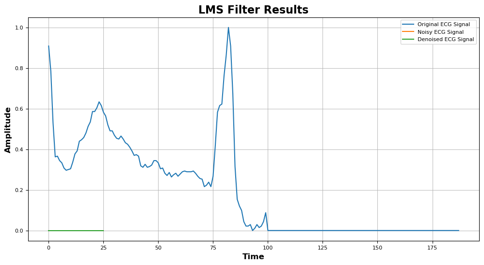

```python
# Plot the result
plt.figure(figsize=(12, 6))
plt.plot(ecg_signals[0], label='Original ECG Signal')
plt.plot(noisy_ecgs[0], label='Noisy ECG Signal')
plt.plot(cleaned_ecgs[0], label='Denoised ECG Signal')
plt.xlabel('Time')
plt.ylabel('Amplitude')
plt.legend()
plt.title('LMS Filter Results')
plt.show()
```

Convergence Monitoring

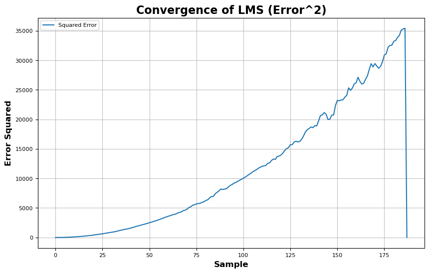

```python
plt.plot(cleaned_ecg**2, label="Squared Error")
plt.title("Convergence of LMS (Error^2)")
plt.xlabel("Sample")
plt.ylabel("Error Squared")
plt.grid(True)
plt.legend()
plt.show()
```

**3. Machine Learning Approach**

1D-CNN Autoencoder Implementation

```python
# Define the input shape
input_shape = (len(noisy_ecgs), 1)

# Define the autoencoder model
input_layer = Input(shape=input_shape)
x = Conv1D(32, kernel_size=3, activation='relu', padding='same')(input_layer)
x = Conv1D(16, kernel_size=3, activation='relu', padding='same')(x)
x = Conv1D(32, kernel_size=3, activation='relu', padding='same')(x)
decoded = Conv1D(1, kernel_size=3, activation='linear', padding='same')(x)

# Define the autoencoder model
autoencoder = Model(input_layer, decoded)

# Compile the model
autoencoder.compile(optimizer='adam', loss='mean_squared_error')

# Reshape the noisy ECG signals
noisy_ecgs_reshaped = np.array(noisy_ecgs).reshape((-1, len(noisy_ecgs), 1))

# Train the autoencoder
autoencoder.fit(noisy_ecgs_reshaped, noisy_ecgs_reshaped, epochs=50, batch_size=32, verbose=2)

# Use the autoencoder to denoise the ECG signals
denoised_ecgs = autoencoder.predict(noisy_ecgs_reshaped)
denoised_ecgs = denoised_ecgs.reshape((-1, len(noisy_ecgs)))

# Save Denoised Dataset
df = pd.DataFrame(denoised_ecgs_aem)
df.to_csv('filtered_aem_signals.csv', index=False)
```

```
1/1 - 3s - 3s/step - loss: 588.4544
1/1 - 0s - 117ms/step - loss: 568.1446
1/1 - 0s - 118ms/step - loss: 549.9863
1/1 - 0s - 121ms/step - loss: 532.0315
1/1 - 0s - 117ms/step - loss: 513.7845
1/1 - 0s - 117ms/step - loss: 499.4504
1/1 - 0s - 117ms/step - loss: 485.5732
1/1 - 0s - 117ms/step - loss: 472.3625
1/1 - 0s - 116ms/step - loss: 459.0912
1/1 - 0s - 124ms/step - loss: 446.1263
1/1 - 0s - 109ms/step - loss: 432.8025
1/1 - 0s - 116ms/step - loss: 419.7423
1/1 - 0s - 117ms/step - loss: 408.1504
1/1 - 0s - 116ms/step - loss: 396.9149
1/1 - 0s - 126ms/step - loss: 385.9397
1/1 - 0s - 101ms/step - loss: 374.5712
1/1 - 0s - 100ms/step - loss: 364.1984
1/1 - 0s - 117ms/step - loss: 353.7135
1/1 - 0s - 118ms/step - loss: 342.8542
1/1 - 0s - 124ms/step - loss: 331.5750
1/1 - 0s - 121ms/step - loss: 319.8493
1/1 - 0s - 132ms/step - loss: 307.2341
1/1 - 0s - 127ms/step - loss: 294.2524
1/1 - 0s - 132ms/step - loss: 280.6890
1/1 - 0s - 127ms/step - loss: 267.1734
1/1 - 0s - 123ms/step - loss: 253.3056
1/1 - 0s - 117ms/step - loss: 238.9489
1/1 - 0s - 119ms/step - loss: 224.5032
1/1 - 0s - 114ms/step - loss: 209.4629
1/1 - 0s - 129ms/step - loss: 193.8338
1/1 - 0s - 116ms/step - loss: 177.7140
1/1 - 0s - 118ms/step - loss: 161.1809
1/1 - 0s - 107ms/step - loss: 144.3607
1/1 - 0s - 119ms/step - loss: 127.4024
1/1 - 0s - 115ms/step - loss: 110.4867
1/1 - 0s - 114ms/step - loss: 93.8224
1/1 - 0s - 126ms/step - loss: 77.6046
1/1 - 0s - 112ms/step - loss: 62.1162
1/1 - 0s - 103ms/step - loss: 47.6936
1/1 - 0s - 131ms/step - loss: 34.6685
1/1 - 0s - 117ms/step - loss: 23.3921
1/1 - 0s - 141ms/step - loss: 14.2184
1/1 - 0s - 148ms/step - loss: 7.4920
1/1 - 0s - 175ms/step - loss: 3.3732
1/1 - 0s - 204ms/step - loss: 1.8502
1/1 - 0s - 205ms/step - loss: 2.7607
1/1 - 0s - 184ms/step - loss: 5.5406
1/1 - 0s - 193ms/step - loss: 9.2921
1/1 - 0s - 154ms/step - loss: 13.0249
1/1 - 0s - 133ms/step - loss: 15.8956
1/1 ━━━━━━━━━━━━━━━━━━━━ 0s 261ms/step
```

```python
denoised_ecgs_aem
```

```
array([ 0.        ,  1.        ,  2.        , ...,  0.08965841,
       -0.07284832,  0.04329043])
```

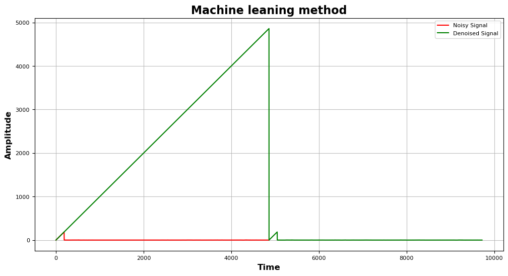

```python
# Plot the original noisy signal and the denoised signal
i = 0
plt.figure(figsize=(12, 6))
plt.plot(noisy_ecgs, label='Noisy Signal', color='red')
plt.plot(denoised_ecgs_aem, label='Denoised Signal', color='green')
plt.xlabel('Time')
plt.ylabel('Amplitude')
plt.title('Machine leaning method')
plt.legend()
plt.grid(True)
plt.show()
```

### EVALUATION FRAMEWORK DEVELOPMENT

Signal Quality Metrics

```python
clean_ecgs = pd.read_csv("ecg_project/data/processed/clean_baseline_signals_normalized.csv", header=None)
clean_ecgs
```

|  | 0 | 1 | 2 | 3 | 4 | 5 | 6 | 7 | 8 | 9 | ... | 177 | 178 | 179 | 180 | 181 | 182 | 183 | 184 | 185 | 186 |
| --- | --- | --- | --- | --- | --- | --- | --- | --- | --- | --- | --- | --- | --- | --- | --- | --- | --- | --- | --- | --- | --- |
| 0 | 1.000000 | 0.758264 | 0.111570 | 0.000000 | 0.080579 | 0.078512 | 0.066116 | 0.049587 | 0.047521 | 0.035124 | ... | 0.000000000000000000e+00.55 | 0.000000000000000000e+00.56 | 0.000000000000000000e+00.57 | 0.000000000000000000e+00.58 | 0.000000000000000000e+00.59 | 0.000000000000000000e+00.60 | 0.000000000000000000e+00.61 | 0.000000000000000000e+00.62 | 0.000000000000000000e+00.63 | 0.000000000000000000e+00.64 |
| 1 | 0.966526 | 0.692349 | 0.030046 | 0.084737 | 0.064055 | 0.060620 | 0.021443 | 0.021265 | 0.003430 | 0.000000 | ... | 0.0 | 0.0 | 0.0 | 0.0 | 0.0 | 0.0 | 0.0 | 0.0 | 0.0 | 0.0 |
| 2 | 0.364316 | 0.000000 | 0.000000 | 0.542736 | 0.684217 | 0.796779 | 0.682279 | 0.623767 | 0.634547 | 0.681596 | ... | 0.0 | 0.0 | 0.0 | 0.0 | 0.0 | 0.0 | 0.0 | 0.0 | 0.0 | 0.0 |
| 3 | 0.943123 | 0.836839 | 0.380406 | 0.288362 | 0.056049 | 0.090551 | 0.074257 | 0.027689 | 0.000000 | 0.029841 | ... | 0.0 | 0.0 | 0.0 | 0.0 | 0.0 | 0.0 | 0.0 | 0.0 | 0.0 | 0.0 |
| 4 | 1.000000 | 0.885862 | 0.639140 | 0.387923 | 0.231847 | 0.227438 | 0.179824 | 0.140680 | 0.091039 | 0.132355 | ... | 0.0 | 0.0 | 0.0 | 0.0 | 0.0 | 0.0 | 0.0 | 0.0 | 0.0 | 0.0 |
| 5 | 1.000000 | 0.902046 | 0.739493 | 1.000000 | 1.000000 | 1.000000 | 0.852551 | 0.809173 | 0.797361 | 0.823071 | ... | 0.0 | 0.0 | 0.0 | 0.0 | 0.0 | 0.0 | 0.0 | 0.0 | 0.0 | 0.0 |
| 6 | 0.998504 | 0.865081 | 0.265904 | 0.215639 | 0.231007 | 0.302990 | 0.249061 | 0.205097 | 0.181383 | 0.200671 | ... | 0.0 | 0.0 | 0.0 | 0.0 | 0.0 | 0.0 | 0.0 | 0.0 | 0.0 | 0.0 |
| 7 | 0.905630 | 0.832334 | 0.487582 | 0.334107 | 0.122036 | 0.123439 | 0.087214 | 0.044083 | 0.020480 | 0.045279 | ... | 0.0 | 0.0 | 0.0 | 0.0 | 0.0 | 0.0 | 0.0 | 0.0 | 0.0 | 0.0 |
| 8 | 1.000000 | 0.887355 | 0.262622 | 0.000000 | 0.084419 | 0.428026 | 0.508681 | 0.507536 | 0.506377 | 0.528575 | ... | 0.0 | 0.0 | 0.0 | 0.0 | 0.0 | 0.0 | 0.0 | 0.0 | 0.0 | 0.0 |
| 9 | 0.476312 | 0.397303 | 0.132838 | 0.382414 | 0.342498 | 0.356416 | 0.318982 | 0.280459 | 0.283394 | 0.301191 | ... | 0.0 | 0.0 | 0.0 | 0.0 | 0.0 | 0.0 | 0.0 | 0.0 | 0.0 | 0.0 |
| 10 | 0.918993 | 0.742490 | 0.386207 | 0.340533 | 0.116710 | 0.282066 | 0.308069 | 0.238298 | 0.204171 | 0.228642 | ... | 0.0 | 0.0 | 0.0 | 0.0 | 0.0 | 0.0 | 0.0 | 0.0 | 0.0 | 0.0 |
| 11 | 1.000000 | 0.827531 | 0.139151 | 0.000000 | 0.072395 | 0.286764 | 0.324155 | 0.345965 | 0.339345 | 0.353708 | ... | 1.0 | 1.0 | 1.0 | 1.0 | 1.0 | 1.0 | 1.0 | 1.0 | 1.0 | 1.0 |
| 12 | 0.967881 | 0.960649 | 0.289265 | 0.000000 | 0.285192 | 0.552366 | 0.398621 | 0.337491 | 0.369454 | 0.386820 | ... | 0.0 | 0.0 | 0.0 | 0.0 | 0.0 | 0.0 | 0.0 | 0.0 | 0.0 | 0.0 |
| 13 | 0.024910 | 0.113456 | 0.089686 | 0.630020 | 0.781601 | 0.921416 | 0.934985 | 0.983438 | 1.000000 | 0.999675 | ... | 0.0 | 0.0 | 0.0 | 0.0 | 0.0 | 0.0 | 0.0 | 0.0 | 0.0 | 0.0 |
| 14 | 1.000000 | 0.967893 | 0.869954 | 0.488569 | 0.146094 | 0.272005 | 0.212320 | 0.101781 | 0.063947 | 0.105279 | ... | 0.0 | 0.0 | 0.0 | 0.0 | 0.0 | 0.0 | 0.0 | 0.0 | 0.0 | 0.0 |
| 15 | 0.971655 | 0.905310 | 0.563047 | 0.355352 | 0.244022 | 0.313631 | 0.259861 | 0.207847 | 0.185212 | 0.201588 | ... | 0.0 | 0.0 | 0.0 | 0.0 | 0.0 | 0.0 | 0.0 | 0.0 | 0.0 | 0.0 |
| 16 | 0.547184 | 0.981860 | 1.000000 | 0.262004 | 0.347971 | 0.856469 | 0.953394 | 0.861650 | 0.914550 | 0.893407 | ... | 0.0 | 0.0 | 0.0 | 0.0 | 0.0 | 0.0 | 0.0 | 0.0 | 0.0 | 0.0 |
| 17 | 0.957479 | 1.000000 | 0.284857 | 0.000000 | 0.305884 | 0.567281 | 0.457035 | 0.383116 | 0.381145 | 0.411920 | ... | 0.0 | 0.0 | 0.0 | 0.0 | 0.0 | 0.0 | 0.0 | 0.0 | 0.0 | 0.0 |
| 18 | 0.890242 | 0.685911 | 0.198905 | 0.000000 | 0.000000 | 0.071850 | 0.121275 | 0.177831 | 0.188133 | 0.231884 | ... | 0.0 | 0.0 | 0.0 | 0.0 | 0.0 | 0.0 | 0.0 | 0.0 | 0.0 | 0.0 |
| 19 | 0.966247 | 0.843257 | 0.570459 | 0.525409 | 0.107353 | 0.000000 | 0.000000 | 0.000000 | 0.009326 | 0.059219 | ... | 0.0 | 0.0 | 0.0 | 0.0 | 0.0 | 0.0 | 0.0 | 0.0 | 0.0 | 0.0 |
| 20 | 1.000000 | 0.855424 | 0.297245 | 0.361602 | 0.409555 | 0.418077 | 0.328886 | 0.298329 | 0.269997 | 0.289851 | ... | 0.0 | 0.0 | 0.0 | 0.0 | 0.0 | 0.0 | 0.0 | 0.0 | 0.0 | 0.0 |
| 21 | 0.997799 | 0.918724 | 0.537379 | 0.424338 | 0.280431 | 0.273488 | 0.197447 | 0.147455 | 0.124706 | 0.134246 | ... | 0.0 | 0.0 | 0.0 | 0.0 | 0.0 | 0.0 | 0.0 | 0.0 | 0.0 | 0.0 |
| 22 | 0.949897 | 0.930622 | 0.155362 | 0.000000 | 0.298888 | 0.506021 | 0.403320 | 0.349225 | 0.342517 | 0.361198 | ... | 0.0 | 0.0 | 0.0 | 0.0 | 0.0 | 0.0 | 0.0 | 0.0 | 0.0 | 0.0 |
| 23 | 0.000000 | 0.095237 | 0.081645 | 0.656294 | 0.811258 | 0.942051 | 1.000000 | 1.000000 | 0.996363 | 1.000000 | ... | 0.0 | 0.0 | 0.0 | 0.0 | 0.0 | 0.0 | 0.0 | 0.0 | 0.0 | 0.0 |
| 24 | 0.972238 | 0.983918 | 0.816167 | 0.383633 | 0.091416 | 0.276416 | 0.165048 | 0.023583 | 0.002483 | 0.029007 | ... | 0.0 | 0.0 | 0.0 | 0.0 | 0.0 | 0.0 | 0.0 | 0.0 | 0.0 | 0.0 |
| 25 | 1.000000 | 0.775773 | 0.135132 | 0.163472 | 0.065920 | 0.099119 | 0.043028 | 0.015038 | 0.014396 | 0.023695 | ... | 0.0 | 0.0 | 0.0 | 0.0 | 0.0 | 0.0 | 0.0 | 0.0 | 0.0 | 0.0 |

26 rows × 187 columns

```python
clean_ecgs.info()
```

```
<class 'pandas.core.frame.DataFrame'>
RangeIndex: 26 entries, 0 to 25
Columns: 187 entries, 0 to 186
dtypes: float64(63), object(124)
memory usage: 38.1+ KB
```

```python
noisy_ecgs = pd.read_csv("ecg_project/data/processed/noisy_ecgs_snr10.csv", header=None)
noisy_ecgs
```

|  | 0 | 1 | 2 | 3 | 4 | 5 | 6 | 7 | 8 | 9 | ... | 177 | 178 | 179 | 180 | 181 | 182 | 183 | 184 | 185 | 186 |
| --- | --- | --- | --- | --- | --- | --- | --- | --- | --- | --- | --- | --- | --- | --- | --- | --- | --- | --- | --- | --- | --- |
| 0 | 0.000000 | 1.000000 | 2.000000 | 3.000000 | 4.000000 | 5.000000 | 6.000000 | 7.000000 | 8.000000 | 9.000000 | ... | 177.000000 | 178.000000 | 179.000000 | 180.000000 | 181.000000 | 182.000000 | 183.000000 | 184.000000 | 185.000000 | 186.000000 |
| 1 | 1.181757 | 0.838715 | 0.163480 | 0.024267 | 0.071915 | -0.073875 | -0.135594 | 0.094821 | 0.045737 | 0.166458 | ... | -0.306510 | -0.111583 | -0.200077 | -0.057372 | -0.028126 | -0.003278 | -0.112649 | -0.170180 | -0.148416 | -0.059042 |
| 2 | 0.288569 | 0.061593 | 0.106466 | 0.609099 | 0.801195 | 0.966194 | 0.754211 | 0.261558 | 0.333020 | 0.932643 | ... | 0.162880 | -0.010709 | -0.233962 | -0.105225 | 0.177316 | 0.168855 | -0.484819 | -0.047123 | -0.353439 | -0.467254 |
| 3 | 0.946462 | 0.854008 | 0.329415 | 0.338773 | 0.044373 | -0.049716 | 0.150689 | 0.140219 | 0.116345 | 0.218604 | ... | -0.389522 | -0.177177 | -0.184733 | -0.021916 | -0.109329 | -0.104731 | -0.123385 | -0.233207 | -0.132114 | -0.172741 |
| 4 | 0.871264 | 0.983658 | 0.747802 | 0.465604 | -0.025130 | 0.112054 | 0.172761 | 0.268166 | 0.038628 | 0.322122 | ... | 0.059400 | -0.235338 | -0.001901 | -0.290257 | 0.010073 | -0.060736 | -0.206208 | -0.147172 | -0.212164 | -0.202078 |
| 5 | 1.056168 | 1.166075 | 0.825102 | 0.972838 | 1.105966 | 1.036675 | 0.565804 | 0.693250 | 0.701606 | 1.013036 | ... | -0.135122 | -0.174829 | -0.195358 | 0.347192 | 0.044519 | -0.000736 | 0.170515 | -0.003715 | -0.100866 | 0.070903 |
| 6 | 0.947371 | 1.073091 | 0.190369 | 0.337727 | 0.004837 | 0.363963 | 0.392961 | 0.188938 | 0.290099 | 0.229729 | ... | -0.150137 | 0.002003 | 0.153527 | -0.036631 | -0.018137 | 0.057341 | -0.225456 | -0.234186 | -0.036991 | 0.241118 |
| 7 | 1.000408 | 0.986882 | 0.440591 | 0.484886 | 0.104158 | -0.050074 | -0.026202 | 0.500254 | -0.015321 | 0.084356 | ... | -0.053341 | 0.301073 | 0.181538 | 0.201452 | 0.376642 | 0.405851 | 0.292121 | 0.038846 | -0.023448 | 0.160386 |
| 8 | 1.155746 | 0.895082 | 0.163590 | 0.057275 | -0.343686 | 0.503308 | 0.144192 | 0.708135 | 0.797835 | 0.452690 | ... | -0.083250 | -0.097855 | -0.076282 | -0.173189 | -0.067973 | -0.028969 | -0.100628 | -0.418032 | -0.259822 | -0.342976 |
| 9 | 0.393401 | 0.571771 | -0.015220 | 0.353199 | 0.308382 | 0.436111 | 0.296097 | 0.123431 | 0.323602 | 0.608659 | ... | -0.125468 | -0.021055 | 0.036927 | 0.111494 | 0.147413 | 0.064775 | -0.028327 | -0.095877 | -0.123574 | 0.086238 |
| 10 | 0.894558 | 0.793607 | 0.330695 | 0.254307 | 0.198302 | 0.250538 | 0.094916 | 0.212580 | 0.114122 | 0.392720 | ... | -0.133540 | 0.108957 | 0.363342 | 0.218440 | 0.219902 | 0.003040 | 0.117945 | 0.114970 | 0.116722 | 0.019268 |
| 11 | 0.745258 | 0.987350 | 0.418233 | 0.685190 | 0.048400 | 0.561188 | -0.007961 | 0.434233 | 0.084624 | 0.219261 | ... | 0.961183 | 1.206423 | 1.312975 | 1.215310 | 1.198148 | 1.229615 | 0.685577 | 1.120307 | 0.862128 | 0.833213 |
| 12 | 1.097382 | 1.101421 | 0.578283 | 0.171558 | 0.348801 | 0.386566 | 0.172613 | 0.355587 | 0.278789 | 0.593493 | ... | 0.312600 | 0.070690 | 0.025924 | 0.001372 | 0.319591 | 0.321725 | 0.102082 | -0.014768 | 0.117683 | 0.186604 |
| 13 | -0.134810 | 0.098462 | 0.022425 | 0.603767 | 0.756880 | 0.494807 | 0.659461 | 0.976154 | 1.435224 | 1.100228 | ... | -0.018486 | -0.490841 | -0.093345 | -0.078843 | 0.225174 | 0.420066 | -0.347297 | -0.553130 | -0.075661 | 0.295561 |
| 14 | 1.030158 | 0.900019 | 0.851972 | 0.732797 | -0.066508 | 0.198567 | 0.116335 | 0.068442 | 0.072846 | 0.063970 | ... | 0.088308 | -0.096569 | 0.076912 | 0.197628 | 0.227204 | 0.158227 | -0.010739 | -0.066771 | -0.190554 | 0.005220 |
| 15 | 0.980937 | 1.154135 | 0.566788 | 0.302955 | 0.201991 | 0.264487 | 0.219932 | 0.101602 | 0.196042 | 0.350250 | ... | 0.063639 | 0.021011 | 0.174963 | -0.018559 | 0.208190 | 0.316654 | 0.159534 | 0.112898 | 0.156943 | 0.212155 |
| 16 | 0.936421 | 1.167956 | 1.049744 | 0.230007 | 0.378940 | 0.703204 | 0.868116 | 0.826952 | 0.883831 | 1.232491 | ... | 0.199245 | -0.254958 | -0.139811 | 0.177080 | 0.217152 | -0.051653 | 0.138667 | 0.118858 | -0.068557 | 0.046671 |
| 17 | 1.188948 | 1.070474 | 0.358112 | 0.050801 | 0.410215 | 0.637918 | 0.297304 | 0.391258 | 0.525133 | 0.367704 | ... | 0.021822 | -0.132325 | -0.070663 | -0.109977 | 0.142661 | -0.198737 | -0.152823 | -0.252031 | -0.119004 | -0.005171 |
| 18 | 0.849501 | 0.724443 | 0.367367 | -0.247996 | 0.009833 | -0.038830 | 0.198301 | 0.114297 | 0.463246 | 0.412430 | ... | 0.106507 | 0.092882 | -0.048299 | 0.362889 | 0.236319 | -0.015497 | 0.273120 | 0.228429 | 0.211998 | 0.324334 |
| 19 | 1.055396 | 0.574791 | 0.702099 | 0.679543 | -0.177061 | -0.067425 | -0.345573 | 0.000126 | 0.309994 | 0.331134 | ... | 0.298361 | 0.076163 | 0.461256 | 0.553507 | 0.221433 | 0.459323 | 0.011014 | 0.165488 | 0.137961 | 0.036045 |
| 20 | 1.104335 | 0.823926 | 0.438093 | 0.501813 | 0.490225 | 0.374538 | 0.304326 | 0.198155 | 0.320778 | 0.542017 | ... | -0.104761 | 0.147595 | 0.088939 | 0.301916 | 0.229579 | 0.147730 | 0.237461 | -0.195348 | 0.049462 | 0.095772 |
| 21 | 1.082421 | 0.813887 | 0.676071 | 0.498222 | 0.108313 | 0.213609 | 0.207510 | 0.170476 | 0.193618 | 0.202636 | ... | 0.061637 | 0.135242 | 0.439181 | 0.388571 | 0.260850 | 0.229815 | 0.018852 | 0.234290 | 0.206718 | 0.181505 |
| 22 | 0.797682 | 0.915597 | 0.188266 | -0.129612 | 0.077394 | 0.273594 | 0.503487 | 0.490553 | 0.253892 | 0.371688 | ... | -0.274342 | -0.241527 | -0.147050 | 0.099000 | -0.119337 | -0.501825 | -0.352754 | -0.213625 | -0.226825 | -0.034862 |
| 23 | 0.546902 | 0.488200 | 0.206552 | 0.466920 | 0.786616 | 0.504056 | 0.719838 | 0.637310 | 1.002878 | 0.901904 | ... | -0.298023 | -0.321870 | -0.152539 | -0.438436 | 0.162717 | 0.070181 | -0.010154 | -0.330128 | -0.269295 | 0.238169 |
| 24 | 0.972584 | 1.117078 | 1.125508 | 0.324017 | -0.115263 | 0.240306 | 0.144551 | 0.066211 | 0.025304 | 0.310810 | ... | 0.146864 | 0.262555 | -0.044791 | 0.232619 | 0.083705 | 0.056284 | 0.339265 | 0.108513 | -0.044708 | 0.084087 |
| 25 | 0.874156 | 0.737884 | 0.139729 | 0.156350 | 0.017599 | 0.051754 | 0.069057 | -0.100851 | -0.002662 | 0.086865 | ... | 0.088117 | 0.060093 | 0.137390 | 0.118001 | 0.074077 | 0.166620 | 0.096590 | 0.101070 | -0.046318 | -0.061444 |

26 rows × 187 columns

```python
# save all denoised ECG signals to a single CSV file with multiple columns
denoised_ecgs_aem = pd.read_csv('filtered_aem_signals.csv', header=None).values.flatten()
denoised_ecgs_lms = pd.read_csv('filtered_lms_signals.csv', header=None).values.flatten()
denoised_ecgs_wt = pd.read_csv('filtered_wt_signals.csv', header=None).values.flatten()
denoised_ecgs_bw = pd.read_csv('filtered_bw_signals.csv').values.flatten()

# Ensure all arrays have the same length
min_len = min(len(denoised_ecgs_aem), len(denoised_ecgs_lms), len(denoised_ecgs_wt), len(denoised_ecgs_bw))

denoised_ecgs_df = pd.DataFrame({
    'AEM': denoised_ecgs_aem[:min_len],
    'LMS': denoised_ecgs_lms[:min_len],
    'WT': denoised_ecgs_wt[:min_len],
    'BW': denoised_ecgs_bw[:min_len]
})

denoised_ecgs_df.to_csv('denoised_ecgs.csv', index=False)
```

```python
denoised_ecgs_df = pd.read_csv('denoised_ecgs.csv')
print(denoised_ecgs_df)
```

```
         AEM       LMS        WT        BW
0        0.0  0.000000  0.000000  1.179100
1        0.0  1.000000  1.000000  0.043303
2        1.0  2.000000  2.000000 -0.041022
3        2.0  3.000000  3.000000  0.952742
4        3.0  4.000000  4.000000 -0.275616
...      ...       ...       ...       ...
4695  4694.0  0.005523  0.165787  0.728113
4696  4695.0  0.005523  0.092793  0.423609
4697  4696.0  0.005523  0.104242  0.522982
4698  4697.0  0.005523 -0.042858  0.784472
4699  4698.0  0.005523  0.000759  0.736813

[4700 rows x 4 columns]
```

```python
# Function to clean and convert problematic float strings
def clean_float_string(value):
    """
    Clean and convert problematic float strings to proper format
    """
    if isinstance(value, str):
        # Fix malformed scientific notation (e.g., 'Se-02.1' -> 'e-02')
        value = re.sub(r'Se-(\d+)\.?\d*', r'e-\1', value)
        # Fix other potential issues with scientific notation
        value = re.sub(r'([0-9])([Se])([+-]?\d+)', r'\1e\3', value)
        # Remove any trailing periods in exponents
        value = re.sub(r'e([+-]?\d+)\.\d*', r'e\1', value)
    return value
```

```python
# Function to safely convert to float with error handling
def safe_float_conversion(data):
    """
    Safely convert data to float, handling problematic values
    """
    # Convert to pandas Series if it's a numpy array
    if isinstance(data, np.ndarray):
        data = pd.Series(data.flatten())
    elif not isinstance(data, pd.Series):
        data = pd.Series(data)

    # First, apply string cleaning
    cleaned_series = data.astype(str).apply(clean_float_string)

    # Try to convert to float, replacing errors with NaN
    try:
        return pd.to_numeric(cleaned_series, errors='coerce').values
    except:
        # If that fails, try element by element
        result = []
        for val in cleaned_series:
            try:
                result.append(float(val))
            except:
                result.append(np.nan)
        return np.array(result)
```

```python
# Load clean and noisy ECG signals with error handling
try:
    clean_ecgs = pd.read_csv("ecg_project/data/processed/clean_baseline_signals_normalized.csv", header=None)
    clean_ecgs = safe_float_conversion(clean_ecgs_df.values.flatten())
    print(f"Clean ECG data loaded successfully. Shape: {len(clean_ecgs)}")
except Exception as e:
    print(f"Error loading clean ECG data: {e}")
    clean_ecgs = None

try:
    noisy_ecgs = pd.read_csv("ecg_project/data/processed/noisy_ecgs_snr10.csv", header=None)
    noisy_ecgs = safe_float_conversion(noisy_ecgs_df.values.flatten())
    print(f"Noisy ECG data loaded successfully. Shape: {len(noisy_ecgs)}")
except Exception as e:
    print(f"Error loading noisy ECG data: {e}")
    noisy_ecgs = None

# Load denoised signals with error handling
try:
    denoised_ecgs_df = pd.read_csv('denoised_ecgs.csv', index_col=False)
    print(f"Denoised ECG data loaded successfully. Shape: {denoised_ecgs_df.shape}")
except Exception as e:
    print(f"Error loading denoised ECG data: {e}")
    denoised_ecgs_df = None
```

```
Clean ECG data loaded successfully. Shape: 4862
Noisy ECG data loaded successfully. Shape: 4862
Denoised ECG data loaded successfully. Shape: (4700, 4)
```

```python
# Define a function to calculate SNR improvement
def calculate_snr_improvement(noisy_signal, clean_signal, denoised_signal):
    """
    Calculate SNR improvement between noisy and denoised signals
    """
    # Remove NaN values
    mask = ~(np.isnan(noisy_signal) | np.isnan(clean_signal) | np.isnan(denoised_signal))
    noisy_signal = noisy_signal[mask]
    clean_signal = clean_signal[mask]
    denoised_signal = denoised_signal[mask]

    if len(noisy_signal) == 0:
        return np.nan

    # Calculate noise components
    noise_noisy = noisy_signal - clean_signal
    noise_denoised = denoised_signal - clean_signal

    # Calculate SNR values (in dB)
    # Adding small epsilon to avoid division by zero
    eps = 1e-10
    snr_noisy = 10 * np.log10((np.mean(clean_signal**2) + eps) / (np.mean(noise_noisy**2) + eps))
    snr_denoised = 10 * np.log10((np.mean(clean_signal**2) + eps) / (np.mean(noise_denoised**2) + eps))

    # Calculate improvement
    snr_improvement = snr_denoised - snr_noisy
    return snr_improvement
```

```python
# Additional function to calculate individual SNR values
def calculate_snr(signal, clean_signal):
    """
    Calculate SNR of a signal compared to clean reference
    """
    # Remove NaN values
    mask = ~(np.isnan(signal) | np.isnan(clean_signal))
    signal = signal[mask]
    clean_signal = clean_signal[mask]

    if len(signal) == 0:
        return np.nan

    # Calculate noise
    noise = signal - clean_signal

    # Calculate SNR (in dB)
    eps = 1e-10
    snr = 10 * np.log10((np.mean(clean_signal**2) + eps) / (np.mean(noise**2) + eps))

    return snr

# Check if all data is loaded successfully
if clean_ecgs is not None and noisy_ecgs is not None and denoised_ecgs_df is not None:
    # First calculate SNR for clean and noisy signals
    min_length_base = min(len(clean_ecgs), len(noisy_ecgs))

    # Calculate SNR for noisy signal
    snr_noisy = calculate_snr(noisy_ecgs[:min_length_base], clean_ecgs[:min_length_base])
    print(f"SNR (Noisy ECG): {snr_noisy:.4f} dB")

    # Calculate SNR for clean signal (should be very high/infinite)
    snr_clean = calculate_snr(clean_ecgs[:min_length_base], clean_ecgs[:min_length_base])
    print(f"SNR (Clean ECG): {snr_clean:.4f} dB")

    print("\n" + "-"*50)
    print("DENOISED SIGNALS SNR IMPROVEMENTS")
    print("-"*50)

    # Calculate SNR improvement for each denoising method
    results = {
        'noisy': snr_noisy,
        'clean': snr_clean
    }

    for column in denoised_ecgs_df.columns:
        try:
            denoised_signal = safe_float_conversion(denoised_ecgs_df[column].values)

            # Ensure all signals have the same length
            min_length = min(len(clean_ecgs), len(noisy_ecgs), len(denoised_signal))

            # Calculate SNR for denoised signal
            snr_denoised = calculate_snr(denoised_signal[:min_length], clean_ecgs[:min_length])

            # Calculate improvement
            snr_improvement = calculate_snr_improvement(
                noisy_ecgs[:min_length],
                clean_ecgs[:min_length],
                denoised_signal[:min_length]
            )

            results[column] = snr_denoised
            results[f'{column}_improvement'] = snr_improvement

            print(f"SNR ({column}): {snr_denoised:.4f} dB")
            print(f"SNR Improvement ({column}): {snr_improvement:.4f} dB")
            print()

        except Exception as e:
            print(f"Error calculating SNR for {column}: {e}")
            results[column] = np.nan
            results[f'{column}_improvement'] = np.nan

    # Display comprehensive summary
    print("\n" + "="*60)
    print("COMPREHENSIVE SNR ANALYSIS SUMMARY")
    print("="*60)
    print(f"{'Signal Type':<25} {'SNR (dB)':<12} {'Improvement (dB)':<15}")
    print("-"*60)
    print(f"{'Original Noisy':<25} {snr_noisy:<12.4f} {'--':<15}")
    print(f"{'Clean Reference':<25} {snr_clean:<12.4f} {'--':<15}")
    print("-"*60)

    for column in denoised_ecgs_df.columns:
        if column in results and f'{column}_improvement' in results:
            snr_val = results[column]
            improvement_val = results[f'{column}_improvement']
            if not np.isnan(snr_val) and not np.isnan(improvement_val):
                print(f"{column:<25} {snr_val:<12.4f} {improvement_val:<15.4f}")
            else:
                print(f"{column:<25} {'ERROR':<12} {'ERROR':<15}")

    print("\n" + "="*60)
    print("NOTES:")
    print("- SNR values are in decibels (dB)")
    print("- Higher SNR values indicate better signal quality")
    print("- Positive improvement values indicate successful denoising")
    print("- Clean reference SNR should be very high (near infinite)")

else:
    print("Could not load all required data files. Please check file paths and data integrity.")
```

```
SNR (Noisy ECG): -35.0988 dB
SNR (Clean ECG): 91.3792 dB

--------------------------------------------------
DENOISED SIGNALS SNR IMPROVEMENTS
--------------------------------------------------
SNR (AEM): -77.1560 dB
SNR Improvement (AEM): -42.0408 dB

SNR (LMS): -9.7133 dB
SNR Improvement (LMS): 25.4018 dB

SNR (WT): -9.4497 dB
SNR Improvement (WT): 25.6655 dB

SNR (BW): -2.1266 dB
SNR Improvement (BW): 32.9886 dB


============================================================
COMPREHENSIVE SNR ANALYSIS SUMMARY
============================================================
Signal Type               SNR (dB)     Improvement (dB)
------------------------------------------------------------
Original Noisy            -35.0988     --
Clean Reference           91.3792      --
------------------------------------------------------------
AEM                       -77.1560     -42.0408
LMS                       -9.7133      25.4018
WT                        -9.4497      25.6655
BW                        -2.1266      32.9886

============================================================
NOTES:
- SNR values are in decibels (dB)
- Higher SNR values indicate better signal quality
- Positive improvement values indicate successful denoising
- Clean reference SNR should be very high (near infinite)
```

Clinical Validation Metrics

```python
# R-peak detection algorithm implementation
def butter_bandpass(lowcut, highcut, fs, order=5):
    nyq = 0.5 * fs
    low = lowcut / nyq
    high = highcut / nyq
    b, a = butter(order, [low, high], btype='band')
    return b, a

def butter_bandpass_filter(data, lowcut, highcut, fs, order=5):
    b, a = butter_bandpass(lowcut, highcut, fs, order=order)
    y = lfilter(b, a, np.array(data, dtype=float))  # Convert data to numpy array
    return y

def detect_r_peaks(ecg_signal, fs):
    filtered_signal = butter_bandpass_filter(ecg_signal, 5, 15, fs)
    peaks, _ = find_peaks(filtered_signal, height=np.mean(filtered_signal) + 2*np.std(filtered_signal))
    return peaks

# Load clean ECGs
clean_ecgs_df = pd.read_csv("ecg_project/data/processed/clean_baseline_signals_normalized.csv", header=None).astype(float)

# Detect R-peaks for clean ECGs
fs = 100.0
reference_peaks = []
for column in clean_ecgs_df.columns:
    ecg_signal = clean_ecgs_df[column].values.flatten()  # Flatten the values
    peaks = detect_r_peaks(ecg_signal, fs)
    reference_peaks.append(peaks)
```

[output not shown]

[output cut: 13 more lines]

[output not shown]